# Danio rerio behavioral data (Data analysis)

- Show All Code
- Hide All Code
- View Source

Supplementary materials and code for Perc et al., Behavioral and Developmental Impacts of Polystyrene and Polyethylene Micro- and Nanoplastics in Zebrafish: Role of Particle Surface Adhesion’

Authors

Affiliations

Valentina Perc

University of Ljubljana, Biotechnical faculty, Department of Biology

Urban Dajčman

National institute of Biology, Slovenia

Published

September 25, 2025

##### Import packages and fix names

```r
rm(list=ls())

library(purrr)
library(readxl)
library(writexl)
library(tidyr)
library(stringr)
library(tools)
library(ggplot2)
library(car)
library(ggpubr)
library(dunn.test)
library(knitr)
library(FSA)
library(kableExtra)
library(scales)
library(forcats)
library(ggridges)
library(dplyr)
```

# Import data

###### Data was wrangled and saved in a separate script avalible for review upon request.

```r
behavior_files <- list.files("Stats/Data_cleaned/Materials_by_time", pattern = "\\.xlsx$", full.names = TRUE)

# Load files into a named list
behavior_files_list <- behavior_files %>%
  set_names(~ stringr::str_remove(basename(.x), "\\.xlsx$")) %>%
  purrr::map(readxl::read_xlsx)

# Drop materials you don't want
behavior_files_list <- behavior_files_list[
  !grepl("^(ag|pc|tio2|ps_eu)_", names(behavior_files_list), ignore.case = TRUE)
]

invisible(NULL)
```

### FUNCTIONS

###### Make a function to identify potential extreme (3*IQR) outliers to remove noise generated by errors during movement capture on the machine

```r
# Function to remove extreme outliers using 3 * IQR method
remove_extreme_outliers <- function(data, value_column, group_column) {
  data %>%
    group_by({{ group_column }}) %>%
    mutate(
      Q1 = quantile({{ value_column }}, 0.25, na.rm = TRUE),
      Q3 = quantile({{ value_column }}, 0.75, na.rm = TRUE),
      IQR = Q3 - Q1,
      lower_bound = Q1 - 3 * IQR,
      upper_bound = Q3 + 3 * IQR,
      is_outlier = if_else({{ value_column }} < lower_bound | {{ value_column }} > upper_bound, TRUE, FALSE)
    ) %>%
    ungroup()
}
```

### Summary function for behaviour

```r
summarise_behavior <- function(data, group_var, vars) {
  out <- data %>%
    dplyr::group_by({{ group_var }}) %>%
    dplyr::summarise(
      dplyr::across(
        dplyr::all_of(vars),
        list(
          mean = ~mean(.x, na.rm = TRUE),
          sd   = ~sd(.x, na.rm = TRUE),
          se   = ~sd(.x, na.rm = TRUE) / sqrt(dplyr::n())
        ),
        .names = "{.col}_{.fn}"
      )
    )
  print(knitr::kable(out, format = "pipe", digits = 3))
  invisible(out)
}
```

### Wilcox plot function

```r
plot_with_wilcox <- function(data, y_var, group_var) {
  # Ensure the grouping variable is a factor
  group_sym <- rlang::ensym(group_var)
  data <- data %>% mutate(!!group_sym := as.factor(!!group_sym))

  # Get group levels and create comparisons vs "c"
  groups <- levels(data[[rlang::as_string(group_sym)]])

  # Check that "c" exists
  if (!"c" %in% groups) stop('"c" must be one of the group levels to compare against.')

  # Compare all other groups to "c" only
  comparisons <- lapply(setdiff(groups, "c"), function(g) c("c", g))

  ggplot(data, aes(x = !!group_sym, y = !!rlang::enquo(y_var))) +
    geom_boxplot() +
    stat_compare_means(
      method = "wilcox.test",
      comparisons = comparisons,
      label = "p.signif",
      hide.ns = FALSE
    ) +
    theme_pubr()
}
```

### Stat test function

```r
run_stats <- function(data, formula, dataset_name) {
  response_var <- all.vars(formula)[1]
  group_var    <- all.vars(formula)[2]

  data[[group_var]] <- as.factor(data[[group_var]])
  data_clean <- dplyr::filter(data, !is.na(.data[[response_var]]), !is.na(.data[[group_var]]))

  v <- data_clean[[response_var]]
  n <- length(v)

  shapiro <- if (n >= 3 && n <= 5000) shapiro.test(v)
             else if (n > 5000)       shapiro.test(sample(v, 5000))
             else                     list(statistic = NA, p.value = NA)

  levene  <- tryCatch(car::leveneTest(formula, data = data_clean), error = function(e) NULL)
  kruskal <- tryCatch(kruskal.test(formula, data = data_clean),   error = function(e) NULL)

  out <- tibble::tibble(
    dataset_name         = dataset_name,
    shapiro_statistic    = unname(shapiro$statistic),
    shapiro_p_value      = shapiro$p.value,
    levene_F_value       = if (!is.null(levene))  levene$`F value`[1]                else NA_real_,
    levene_p_value       = if (!is.null(levene))  levene$`Pr(>F)`[1]                 else NA_real_,
    kruskal_H_statistic  = if (!is.null(kruskal)) as.numeric(kruskal$statistic)      else NA_real_,
    kruskal_df           = if (!is.null(kruskal)) as.numeric(kruskal$parameter)      else NA_real_,
    kruskal_p_value      = if (!is.null(kruskal)) kruskal$p.value                    else NA_real_
  ) |>
    tidyr::pivot_longer(-dataset_name, names_to = "test_metric", values_to = "value") |>
    dplyr::mutate(
      significance = dplyr::case_when(
        grepl("_p_value$", test_metric) & value < 0.001 ~ "***",
        grepl("_p_value$", test_metric) & value < 0.01  ~ "**",
        grepl("_p_value$", test_metric) & value < 0.05  ~ "*",
        TRUE ~ ""
      )
    )

  print(knitr::kable(out, format = "pipe", digits = 3))
  invisible(out)
}
```

### Dunn test function

```r
run_dunn_test <- function(data, response, group, save_path = NULL, label = NULL) {
  formula <- as.formula(paste(response, "~", group))
  dunn <- FSA::dunnTest(formula, data = data, method = "bonferroni")

  dunn_df <- tibble::as_tibble(dunn$res) |>
    dplyr::rename(
      comparison   = Comparison,
      z_statistic  = Z,
      p_value      = P.unadj,
      p_adj        = P.adj
    ) |>
    tidyr::separate(comparison, into = c("group1", "group2"), sep = " - ", remove = FALSE) |>
    dplyr::mutate(
      significance = dplyr::case_when(
        p_adj < 0.001 ~ "***",
        p_adj < 0.01  ~ "**",
        p_adj < 0.05  ~ "*",
        TRUE ~ ""
      ),
      effect = dplyr::case_when(
        significance != "" & z_statistic < 0 ~ paste0("Positive (", group2, " > ", group1, ")"),
        significance != "" & z_statistic > 0 ~ paste0("Negative (", group1, " > ", group2, ")"),
        TRUE ~ ""
      )
    ) |>
    dplyr::select(-group1, -group2)

  if (!is.null(save_path) && !is.null(label)) {
    file_path <- file.path(save_path, paste0(label, "_", response, "_dunn.xlsx"))
    writexl::write_xlsx(dunn_df, file_path)
  }

  print(knitr::kable(dunn_df, format = "pipe", digits = 3))
  invisible(dunn_df)
}
```

## LOOP ANALYSIS FOR ALL MATERIALS

## Results (distance, velocity, activity)

```r
# derive names
all_names      <- names(behavior_files_list)
byMin_names    <- all_names[stringr::str_detect(all_names, "_byMin$")]
activity_names <- all_names[stringr::str_detect(all_names, "_activity$")]

safe_print_plot <- function(p) { try(print(p), silent = TRUE); invisible(NULL) }

## Behavior (by minute)
purrr::walk(byMin_names, function(name) {
  data <- behavior_files_list[[name]] |>
  dplyr::mutate(exposure = relabel_levels(exposure))

  # outlier-cleaned (3*IQR)
  cleaned <- remove_extreme_outliers(data, velocity, exposure) |>
    dplyr::filter(!is_outlier) |>
    dplyr::select(-tidyselect::any_of(c("Q1","Q3","IQR","lower_bound","upper_bound","is_outlier"))) |>
    dplyr::mutate(exposure = droplevels(exposure))

  # quick Ns for callout
  n_raw   <- as.data.frame(table(data$exposure))    |> dplyr::rename(group = Var1, n_raw  = Freq)
  n_clean <- as.data.frame(table(cleaned$exposure)) |> dplyr::rename(group = Var1, n_clean= Freq)
  n_join  <- dplyr::left_join(n_raw, n_clean, by = "group")

 ## Section heading (in ToC) — remapped material + byMin → Distance/Velocity
 cat("\n\n### ", pretty_section_name(name), "\n\n", sep = "")

  ## Open tabset
  cat("::: {.panel-tabset}\n\n", sep = "")

  ## --- Stats tab ---
  cat("#### Stats\n\n", sep = "")
  cat("::: callout-note\n", sep = "")
  cat("**Groups:** ", paste(levels(cleaned$exposure), collapse = ", "), "\n\n", sep = "")
  cat("**N per group (raw → clean):**\n\n", sep = "")
  print(knitr::kable(n_join, format = "pipe"))
  cat("\n:::\n\n", sep = "")

  summarise_behavior(cleaned, exposure, c("velocity","distance_moved"))
  run_stats(cleaned, velocity ~ exposure,       name)
  run_stats(cleaned, distance_moved ~ exposure, name)
  run_dunn_test(cleaned, "velocity",       "exposure",
                save_path = "results_FINAL/Behavior/dunn_results", label = name)
  run_dunn_test(cleaned, "distance_moved", "exposure",
                save_path = "results_FINAL/Behavior/dunn_results", label = paste0(name,"_dist"))

  ## --- Plots tab ---
  cat("\n#### Plots\n\n", sep = "")
  safe_print_plot(plot_with_wilcox(data,    velocity,        exposure))
  safe_print_plot(plot_with_wilcox(data,    distance_moved,  exposure))
  safe_print_plot(plot_with_wilcox(cleaned, velocity,        exposure))
  safe_print_plot(plot_with_wilcox(cleaned, distance_moved,  exposure))

  ## --- Distributions tab ---
  cat("\n#### Distributions\n\n", sep = "")
  p_dens_v <- ggdensity(cleaned, x = "velocity", fill = "exposure",
                        add = "mean", rug = TRUE, color = "exposure") +
              facet_wrap(~ exposure) +
              labs(title = paste("Velocity density –", name))
  p_dens_d <- ggdensity(cleaned, x = "distance_moved", fill = "exposure",
                        add = "mean", rug = TRUE, color = "exposure") +
              facet_wrap(~ exposure) +
              labs(title = paste("Distance moved density –", name))
  safe_print_plot(p_dens_v); safe_print_plot(p_dens_d)

  ## close tabset
  cat("\n:::\n", sep = "")
})
```

### PE MPs Distance/Velocity

**Stats**

**Note**

**Groups:** c, hdpe_0005, hdpe_001, hdpe_01, hdpe_1, hdpe_10, hdpe_100, hdpe_25, hdpe_50, hdpe_75

**N per group (raw → clean):**

| group | n_raw | n_clean |
| --- | --- | --- |
| c | 2700 | 2420 |
| hdpe_0005 | 300 | 260 |
| hdpe_001 | 300 | 199 |
| hdpe_01 | 300 | 250 |
| hdpe_1 | 1500 | 1262 |
| hdpe_10 | 1500 | 1229 |
| hdpe_100 | 1500 | 1273 |
| hdpe_25 | 1500 | 1222 |
| hdpe_50 | 1500 | 1183 |
| hdpe_75 | 1500 | 1178 |

| exposure | velocity_mean | velocity_sd | velocity_se | distance_moved_mean | distance_moved_sd | distance_moved_se |
| --- | --- | --- | --- | --- | --- | --- |
| c | 2.016 | 0.748 | 0.015 | 68.778 | 61.253 | 1.245 |
| hdpe_0005 | 2.360 | 1.254 | 0.078 | 98.415 | 96.878 | 6.008 |
| hdpe_001 | 2.229 | 0.995 | 0.071 | 84.096 | 76.499 | 5.423 |
| hdpe_01 | 2.151 | 1.036 | 0.066 | 86.205 | 78.609 | 4.972 |
| hdpe_1 | 2.096 | 0.752 | 0.021 | 84.847 | 61.402 | 1.728 |
| hdpe_10 | 1.838 | 0.575 | 0.016 | 60.382 | 54.036 | 1.541 |
| hdpe_100 | 1.976 | 0.709 | 0.020 | 66.179 | 58.664 | 1.644 |
| hdpe_25 | 2.043 | 0.793 | 0.023 | 74.247 | 65.740 | 1.881 |
| hdpe_50 | 1.844 | 0.688 | 0.020 | 55.400 | 56.859 | 1.653 |
| hdpe_75 | 2.073 | 0.925 | 0.027 | 70.489 | 73.180 | 2.132 |

| dataset_name | test_metric | value | significance |
| --- | --- | --- | --- |
| hdpe_byMin | shapiro_statistic | 0.851 |  |
| hdpe_byMin | shapiro_p_value | 0.000 | *** |
| hdpe_byMin | levene_F_value | 33.854 |  |
| hdpe_byMin | levene_p_value | 0.000 | *** |
| hdpe_byMin | kruskal_H_statistic | 170.116 |  |
| hdpe_byMin | kruskal_df | 9.000 |  |
| hdpe_byMin | kruskal_p_value | 0.000 | *** |

| dataset_name | test_metric | value | significance |
| --- | --- | --- | --- |
| hdpe_byMin | shapiro_statistic | 0.894 |  |
| hdpe_byMin | shapiro_p_value | 0.000 | *** |
| hdpe_byMin | levene_F_value | 29.421 |  |
| hdpe_byMin | levene_p_value | 0.000 | *** |
| hdpe_byMin | kruskal_H_statistic | 220.167 |  |
| hdpe_byMin | kruskal_df | 9.000 |  |
| hdpe_byMin | kruskal_p_value | 0.000 | *** |

| comparison | z_statistic | p_value | p_adj | significance | effect |
| --- | --- | --- | --- | --- | --- |
| c - hdpe_0005 | -0.158 | 0.875 | 1.000 |  |  |
| c - hdpe_001 | -1.353 | 0.176 | 1.000 |  |  |
| hdpe_0005 - hdpe_001 | -0.950 | 0.342 | 1.000 |  |  |
| c - hdpe_01 | -0.050 | 0.960 | 1.000 |  |  |
| hdpe_0005 - hdpe_01 | 0.079 | 0.937 | 1.000 |  |  |
| hdpe_001 - hdpe_01 | 1.015 | 0.310 | 1.000 |  |  |
| c - hdpe_1 | -4.459 | 0.000 | 0.000 | *** | Positive (hdpe_1 > c) |
| hdpe_0005 - hdpe_1 | -2.122 | 0.034 | 1.000 |  |  |
| hdpe_001 - hdpe_1 | -0.722 | 0.471 | 1.000 |  |  |
| hdpe_01 - hdpe_1 | -2.189 | 0.029 | 1.000 |  |  |
| c - hdpe_10 | 5.772 | 0.000 | 0.000 | *** | Negative (c > hdpe_10) |
| hdpe_0005 - hdpe_10 | 3.113 | 0.002 | 0.083 |  |  |
| hdpe_001 - hdpe_10 | 3.952 | 0.000 | 0.003 | ** | Negative (hdpe_001 > hdpe_10) |
| hdpe_01 - hdpe_10 | 2.962 | 0.003 | 0.138 |  |  |
| hdpe_1 - hdpe_10 | 8.909 | 0.000 | 0.000 | *** | Negative (hdpe_1 > hdpe_10) |
| c - hdpe_100 | 1.410 | 0.159 | 1.000 |  |  |
| hdpe_0005 - hdpe_100 | 0.869 | 0.385 | 1.000 |  |  |
| hdpe_001 - hdpe_100 | 1.950 | 0.051 | 1.000 |  |  |
| hdpe_01 - hdpe_100 | 0.754 | 0.451 | 1.000 |  |  |
| hdpe_1 - hdpe_100 | 5.127 | 0.000 | 0.000 | *** | Negative (hdpe_1 > hdpe_100) |
| hdpe_10 - hdpe_100 | -3.835 | 0.000 | 0.006 | ** | Positive (hdpe_100 > hdpe_10) |
| c - hdpe_25 | -0.334 | 0.738 | 1.000 |  |  |
| hdpe_0005 - hdpe_25 | -0.021 | 0.983 | 1.000 |  |  |
| hdpe_001 - hdpe_25 | 1.152 | 0.249 | 1.000 |  |  |
| hdpe_01 - hdpe_25 | -0.121 | 0.904 | 1.000 |  |  |
| hdpe_1 - hdpe_25 | 3.566 | 0.000 | 0.016 | * | Negative (hdpe_1 > hdpe_25) |
| hdpe_10 - hdpe_25 | -5.295 | 0.000 | 0.000 | *** | Positive (hdpe_25 > hdpe_10) |
| hdpe_100 - hdpe_25 | -1.512 | 0.131 | 1.000 |  |  |
| c - hdpe_50 | 8.342 | 0.000 | 0.000 | *** | Negative (c > hdpe_50) |
| hdpe_0005 - hdpe_50 | 4.471 | 0.000 | 0.000 | *** | Negative (hdpe_0005 > hdpe_50) |
| hdpe_001 - hdpe_50 | 5.165 | 0.000 | 0.000 | *** | Negative (hdpe_001 > hdpe_50) |
| hdpe_01 - hdpe_50 | 4.299 | 0.000 | 0.001 | *** | Negative (hdpe_01 > hdpe_50) |
| hdpe_1 - hdpe_50 | 11.139 | 0.000 | 0.000 | *** | Negative (hdpe_1 > hdpe_50) |
| hdpe_10 - hdpe_50 | 2.302 | 0.021 | 0.960 |  |  |
| hdpe_100 - hdpe_50 | 6.119 | 0.000 | 0.000 | *** | Negative (hdpe_100 > hdpe_50) |
| hdpe_25 - hdpe_50 | 7.543 | 0.000 | 0.000 | *** | Negative (hdpe_25 > hdpe_50) |
| c - hdpe_75 | 1.888 | 0.059 | 1.000 |  |  |
| hdpe_0005 - hdpe_75 | 1.129 | 0.259 | 1.000 |  |  |
| hdpe_001 - hdpe_75 | 2.178 | 0.029 | 1.000 |  |  |
| hdpe_01 - hdpe_75 | 1.011 | 0.312 | 1.000 |  |  |
| hdpe_1 - hdpe_75 | 5.478 | 0.000 | 0.000 | *** | Negative (hdpe_1 > hdpe_75) |
| hdpe_10 - hdpe_75 | -3.313 | 0.001 | 0.042 | * | Positive (hdpe_75 > hdpe_10) |
| hdpe_100 - hdpe_75 | 0.452 | 0.651 | 1.000 |  |  |
| hdpe_25 - hdpe_75 | 1.930 | 0.054 | 1.000 |  |  |
| hdpe_50 - hdpe_75 | -5.560 | 0.000 | 0.000 | *** | Positive (hdpe_75 > hdpe_50) |

| comparison | z_statistic | p_value | p_adj | significance | effect |
| --- | --- | --- | --- | --- | --- |
| c - hdpe_0005 | -2.296 | 0.022 | 0.976 |  |  |
| c - hdpe_001 | -1.713 | 0.087 | 1.000 |  |  |
| hdpe_0005 - hdpe_001 | 0.249 | 0.803 | 1.000 |  |  |
| c - hdpe_01 | -3.088 | 0.002 | 0.091 |  |  |
| hdpe_0005 - hdpe_01 | -0.624 | 0.532 | 1.000 |  |  |
| hdpe_001 - hdpe_01 | -0.829 | 0.407 | 1.000 |  |  |
| c - hdpe_1 | -8.241 | 0.000 | 0.000 | *** | Positive (hdpe_1 > c) |
| hdpe_0005 - hdpe_1 | -2.001 | 0.045 | 1.000 |  |  |
| hdpe_001 - hdpe_1 | -2.095 | 0.036 | 1.000 |  |  |
| hdpe_01 - hdpe_1 | -1.170 | 0.242 | 1.000 |  |  |
| c - hdpe_10 | 3.195 | 0.001 | 0.063 |  |  |
| hdpe_0005 - hdpe_10 | 3.834 | 0.000 | 0.006 | ** | Negative (hdpe_0005 > hdpe_10) |
| hdpe_001 - hdpe_10 | 3.118 | 0.002 | 0.082 |  |  |
| hdpe_01 - hdpe_10 | 4.569 | 0.000 | 0.000 | *** | Negative (hdpe_01 > hdpe_10) |
| hdpe_1 - hdpe_10 | 9.932 | 0.000 | 0.000 | *** | Negative (hdpe_1 > hdpe_10) |
| c - hdpe_100 | 1.059 | 0.290 | 1.000 |  |  |
| hdpe_0005 - hdpe_100 | 2.740 | 0.006 | 0.277 |  |  |
| hdpe_001 - hdpe_100 | 2.138 | 0.032 | 1.000 |  |  |
| hdpe_01 - hdpe_100 | 3.495 | 0.000 | 0.021 | * | Negative (hdpe_01 > hdpe_100) |
| hdpe_1 - hdpe_100 | 8.126 | 0.000 | 0.000 | *** | Negative (hdpe_1 > hdpe_100) |
| hdpe_10 - hdpe_100 | -1.882 | 0.060 | 1.000 |  |  |
| c - hdpe_25 | -1.454 | 0.146 | 1.000 |  |  |
| hdpe_0005 - hdpe_25 | 1.447 | 0.148 | 1.000 |  |  |
| hdpe_001 - hdpe_25 | 0.986 | 0.324 | 1.000 |  |  |
| hdpe_01 - hdpe_25 | 2.220 | 0.026 | 1.000 |  |  |
| hdpe_1 - hdpe_25 | 5.858 | 0.000 | 0.000 | *** | Negative (hdpe_1 > hdpe_25) |
| hdpe_10 - hdpe_25 | -4.033 | 0.000 | 0.002 | ** | Positive (hdpe_25 > hdpe_10) |
| hdpe_100 - hdpe_25 | -2.189 | 0.029 | 1.000 |  |  |
| c - hdpe_50 | 6.771 | 0.000 | 0.000 | *** | Negative (c > hdpe_50) |
| hdpe_0005 - hdpe_50 | 5.694 | 0.000 | 0.000 | *** | Negative (hdpe_0005 > hdpe_50) |
| hdpe_001 - hdpe_50 | 4.784 | 0.000 | 0.000 | *** | Negative (hdpe_001 > hdpe_50) |
| hdpe_01 - hdpe_50 | 6.398 | 0.000 | 0.000 | *** | Negative (hdpe_01 > hdpe_50) |
| hdpe_1 - hdpe_50 | 13.006 | 0.000 | 0.000 | *** | Negative (hdpe_1 > hdpe_50) |
| hdpe_10 - hdpe_50 | 3.150 | 0.002 | 0.073 |  |  |
| hdpe_100 - hdpe_50 | 5.041 | 0.000 | 0.000 | *** | Negative (hdpe_100 > hdpe_50) |
| hdpe_25 - hdpe_50 | 7.140 | 0.000 | 0.000 | *** | Negative (hdpe_25 > hdpe_50) |
| c - hdpe_75 | 2.441 | 0.015 | 0.659 |  |  |
| hdpe_0005 - hdpe_75 | 3.452 | 0.001 | 0.025 | * | Negative (hdpe_0005 > hdpe_75) |
| hdpe_001 - hdpe_75 | 2.780 | 0.005 | 0.244 |  |  |
| hdpe_01 - hdpe_75 | 4.191 | 0.000 | 0.001 | ** | Negative (hdpe_01 > hdpe_75) |
| hdpe_1 - hdpe_75 | 9.204 | 0.000 | 0.000 | *** | Negative (hdpe_1 > hdpe_75) |
| hdpe_10 - hdpe_75 | -0.618 | 0.537 | 1.000 |  |  |
| hdpe_100 - hdpe_75 | 1.239 | 0.215 | 1.000 |  |  |
| hdpe_25 - hdpe_75 | 3.374 | 0.001 | 0.033 | * | Negative (hdpe_25 > hdpe_75) |
| hdpe_50 - hdpe_75 | -3.729 | 0.000 | 0.009 | ** | Positive (hdpe_75 > hdpe_50) |

**Plots**

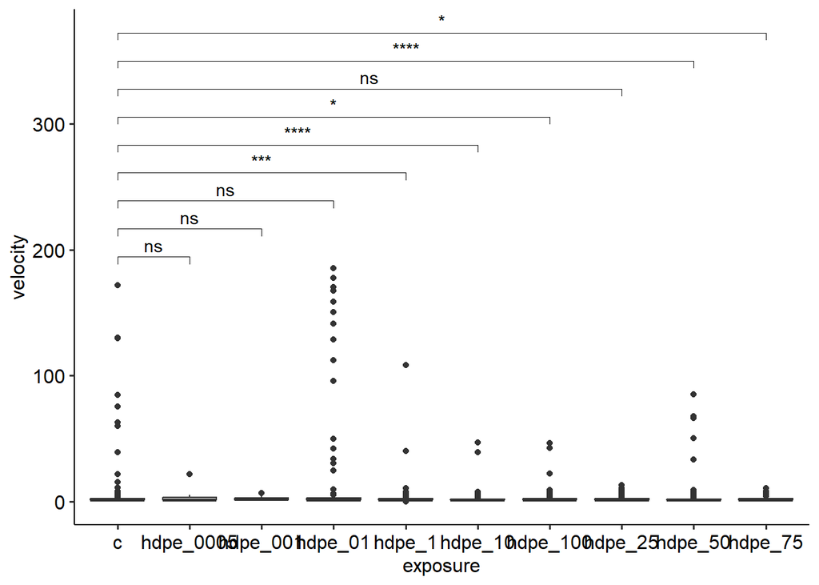

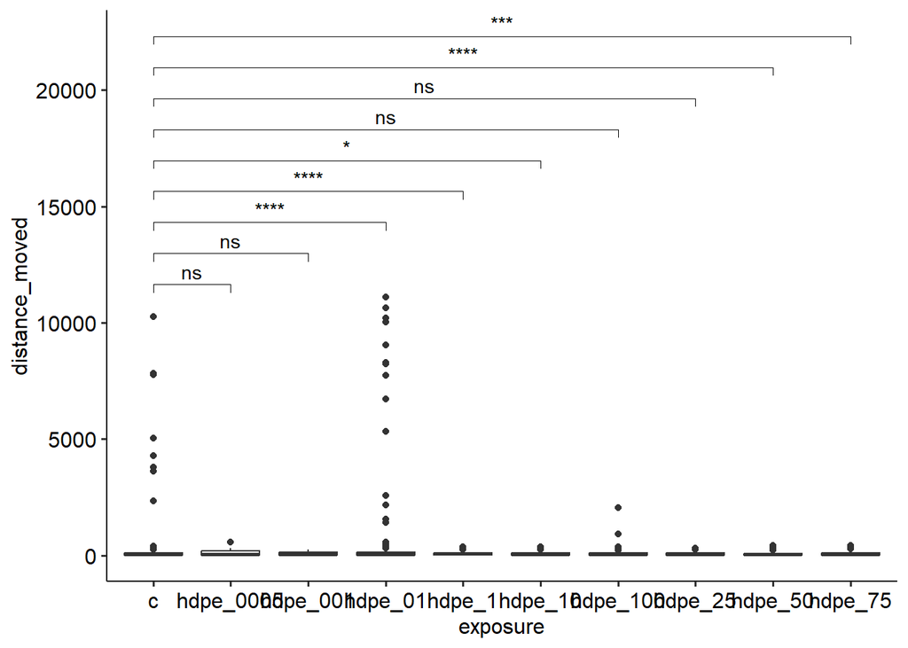

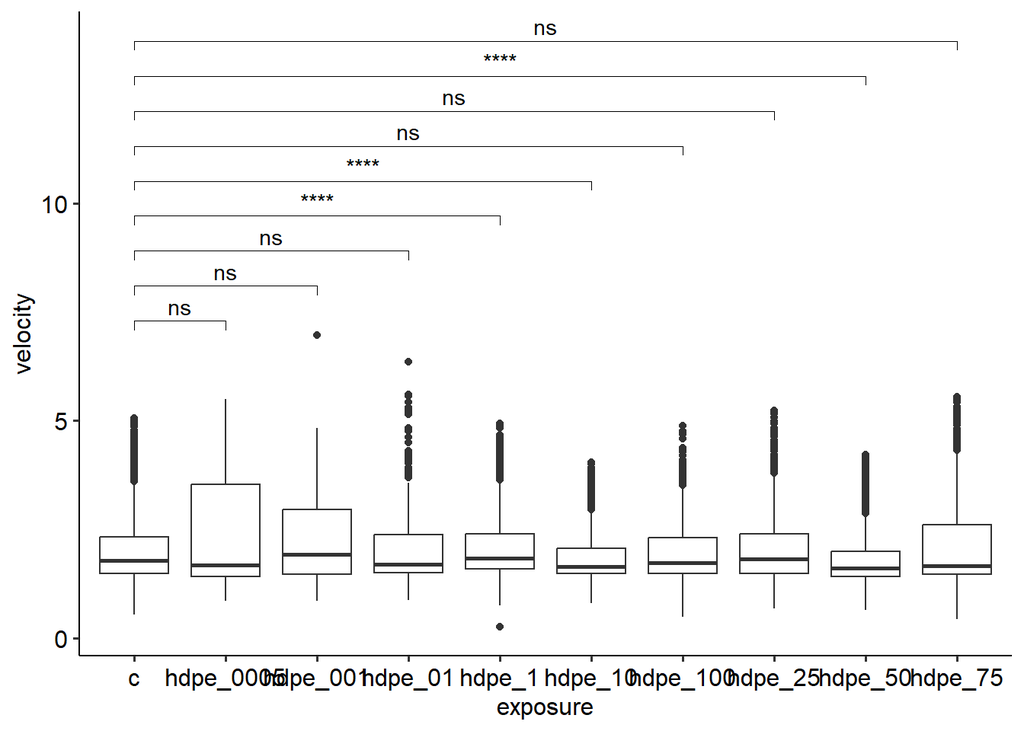

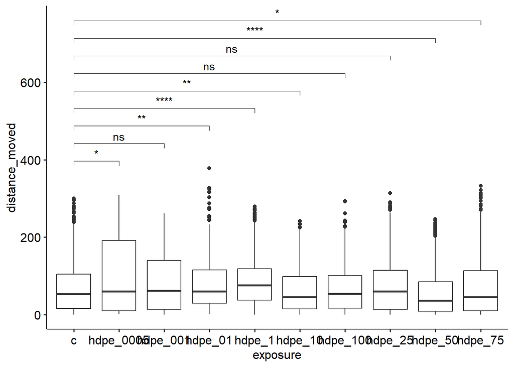

#### Distributions

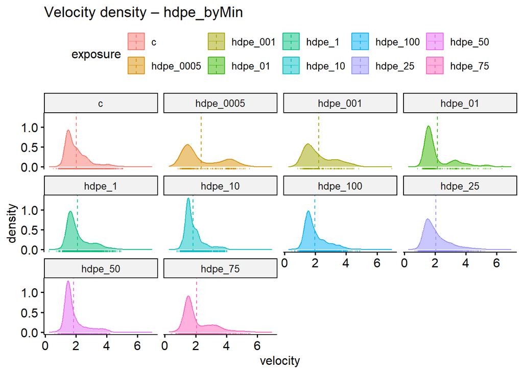

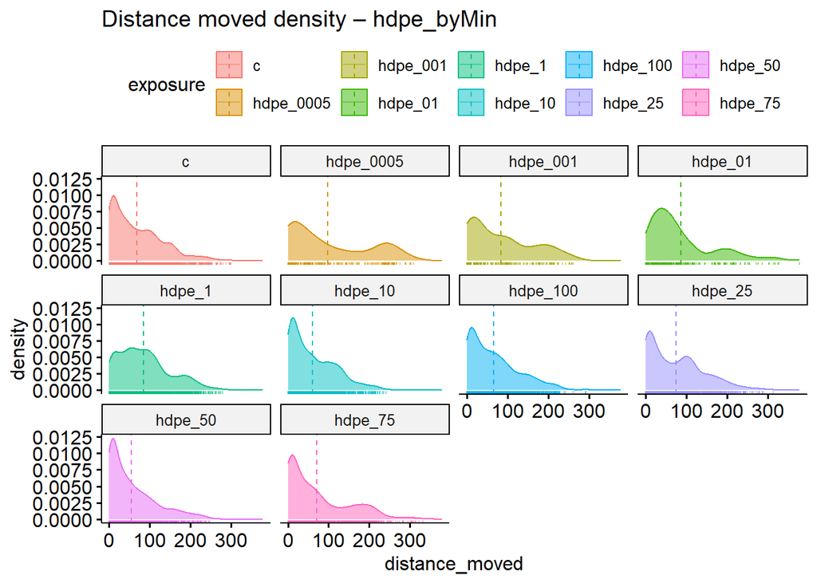

### PE NPs Distance/Velocity

**Stats**

**Note**

**Groups:** c, pen_001, pen_01, pen_1, pen_10, pen_5

**N per group (raw → clean):**

| group | n_raw | n_clean |
| --- | --- | --- |
| c | 1000 | 789 |
| pen_001 | 1800 | 1394 |
| pen_01 | 1800 | 1594 |
| pen_1 | 600 | 497 |
| pen_10 | 600 | 495 |
| pen_5 | 600 | 552 |

| exposure | velocity_mean | velocity_sd | velocity_se | distance_moved_mean | distance_moved_sd | distance_moved_se |
| --- | --- | --- | --- | --- | --- | --- |
| c | 1.708 | 0.459 | 0.016 | 53.058 | 43.874 | 1.562 |
| pen_001 | 1.934 | 0.716 | 0.019 | 64.742 | 57.511 | 1.540 |
| pen_01 | 1.973 | 0.708 | 0.018 | 81.831 | 61.717 | 1.546 |
| pen_1 | 2.070 | 0.855 | 0.038 | 82.559 | 67.961 | 3.048 |
| pen_10 | 1.625 | 0.374 | 0.017 | 42.774 | 41.913 | 1.884 |
| pen_5 | 1.894 | 0.575 | 0.024 | 69.417 | 57.102 | 2.430 |

| dataset_name | test_metric | value | significance |
| --- | --- | --- | --- |
| pen_byMin | shapiro_statistic | 0.847 |  |
| pen_byMin | shapiro_p_value | 0.000 | *** |
| pen_byMin | levene_F_value | 37.958 |  |
| pen_byMin | levene_p_value | 0.000 | *** |
| pen_byMin | kruskal_H_statistic | 183.876 |  |
| pen_byMin | kruskal_df | 5.000 |  |
| pen_byMin | kruskal_p_value | 0.000 | *** |

| dataset_name | test_metric | value | significance |
| --- | --- | --- | --- |
| pen_byMin | shapiro_statistic | 0.918 |  |
| pen_byMin | shapiro_p_value | 0.000 | *** |
| pen_byMin | levene_F_value | 40.844 |  |
| pen_byMin | levene_p_value | 0.000 | *** |
| pen_byMin | kruskal_H_statistic | 236.680 |  |
| pen_byMin | kruskal_df | 5.000 |  |
| pen_byMin | kruskal_p_value | 0.000 | *** |

| comparison | z_statistic | p_value | p_adj | significance | effect |
| --- | --- | --- | --- | --- | --- |
| c - pen_001 | -6.565 | 0.000 | 0.000 | *** | Positive (pen_001 > c) |
| c - pen_01 | -9.047 | 0.000 | 0.000 | *** | Positive (pen_01 > c) |
| pen_001 - pen_01 | -2.764 | 0.006 | 0.086 |  |  |
| c - pen_1 | -7.540 | 0.000 | 0.000 | *** | Positive (pen_1 > c) |
| pen_001 - pen_1 | -2.667 | 0.008 | 0.115 |  |  |
| pen_01 - pen_1 | -0.739 | 0.460 | 1.000 |  |  |
| c - pen_10 | 2.588 | 0.010 | 0.145 |  |  |
| pen_001 - pen_10 | 8.427 | 0.000 | 0.000 | *** | Negative (pen_001 > pen_10) |
| pen_01 - pen_10 | 10.538 | 0.000 | 0.000 | *** | Negative (pen_01 > pen_10) |
| pen_1 - pen_10 | 9.137 | 0.000 | 0.000 | *** | Negative (pen_1 > pen_10) |
| c - pen_5 | -6.092 | 0.000 | 0.000 | *** | Positive (pen_5 > c) |
| pen_001 - pen_5 | -0.906 | 0.365 | 1.000 |  |  |
| pen_01 - pen_5 | 1.130 | 0.259 | 1.000 |  |  |
| pen_1 - pen_5 | 1.516 | 0.130 | 1.000 |  |  |
| pen_10 - pen_5 | -7.859 | 0.000 | 0.000 | *** | Positive (pen_5 > pen_10) |

| comparison | z_statistic | p_value | p_adj | significance | effect |
| --- | --- | --- | --- | --- | --- |
| c - pen_001 | -3.463 | 0.001 | 0.008 | ** | Positive (pen_001 > c) |
| c - pen_01 | -10.138 | 0.000 | 0.000 | *** | Positive (pen_01 > c) |
| pen_001 - pen_01 | -7.826 | 0.000 | 0.000 | *** | Positive (pen_01 > pen_001) |
| c - pen_1 | -7.342 | 0.000 | 0.000 | *** | Positive (pen_1 > c) |
| pen_001 - pen_1 | -5.095 | 0.000 | 0.000 | *** | Positive (pen_1 > pen_001) |
| pen_01 - pen_1 | 0.405 | 0.685 | 1.000 |  |  |
| c - pen_10 | 3.770 | 0.000 | 0.002 | ** | Negative (c > pen_10) |
| pen_001 - pen_10 | 7.080 | 0.000 | 0.000 | *** | Negative (pen_001 > pen_10) |
| pen_01 - pen_10 | 12.777 | 0.000 | 0.000 | *** | Negative (pen_01 > pen_10) |
| pen_1 - pen_10 | 10.025 | 0.000 | 0.000 | *** | Negative (pen_1 > pen_10) |
| c - pen_5 | -4.405 | 0.000 | 0.000 | *** | Positive (pen_5 > c) |
| pen_001 - pen_5 | -1.793 | 0.073 | 1.000 |  |  |
| pen_01 - pen_5 | 3.985 | 0.000 | 0.001 | ** | Negative (pen_01 > pen_5) |
| pen_1 - pen_5 | 2.846 | 0.004 | 0.066 |  |  |
| pen_10 - pen_5 | -7.441 | 0.000 | 0.000 | *** | Positive (pen_5 > pen_10) |

**Plots**

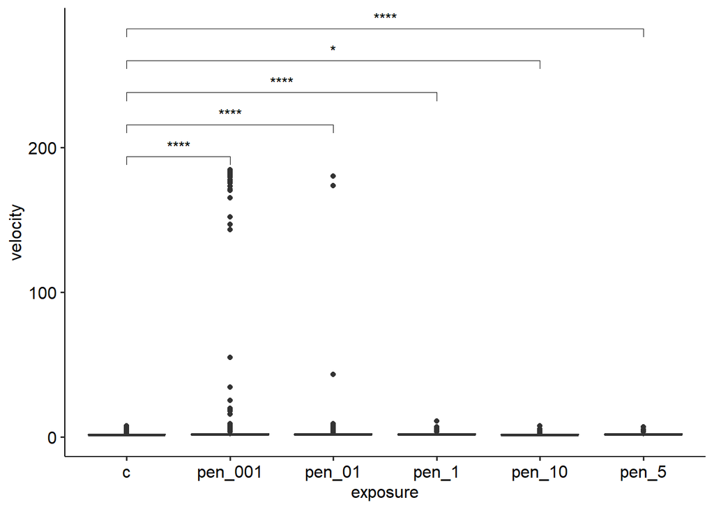

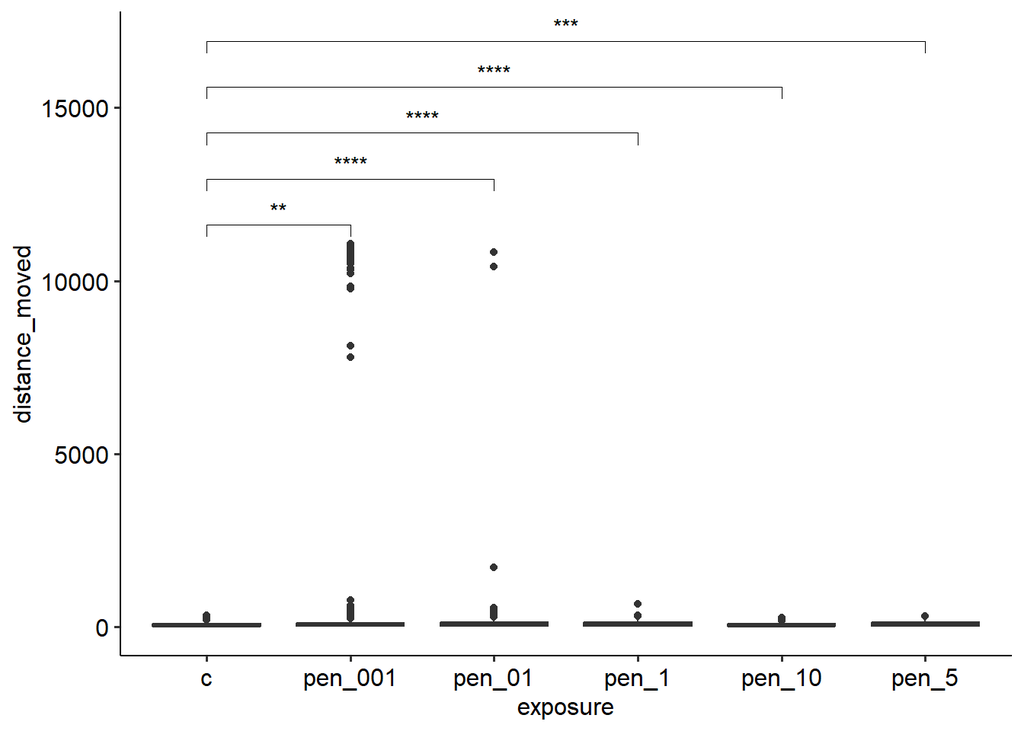

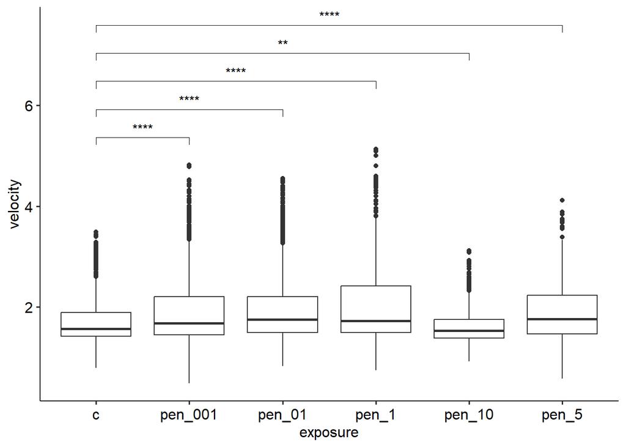

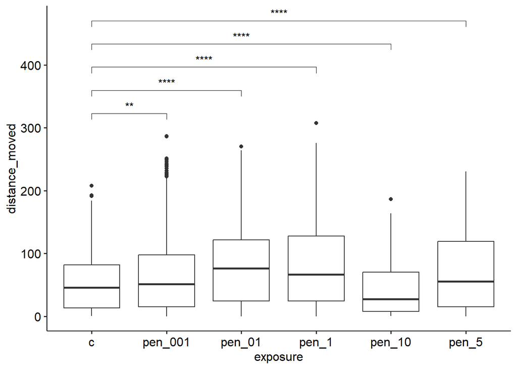

#### Distributions

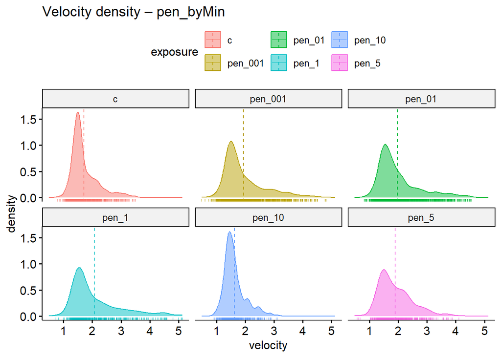

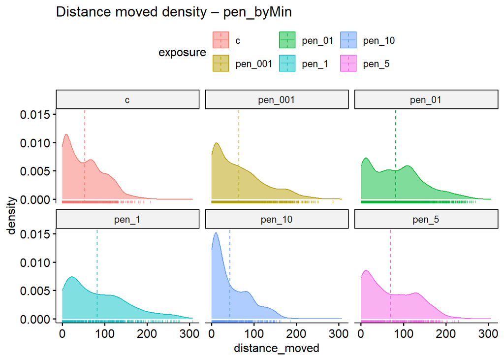

### PS NPs Distance/Velocity

**Stats**

**Note**

**Groups:** c, ps_01_1, ps_01_10, ps_01_100, ps_01_25, ps_01_50, ps_01_75

**N per group (raw → clean):**

| group | n_raw | n_clean |
| --- | --- | --- |
| c | 1800 | 1603 |
| ps_01_1 | 900 | 859 |
| ps_01_10 | 900 | 789 |
| ps_01_100 | 900 | 615 |
| ps_01_25 | 900 | 742 |
| ps_01_50 | 900 | 773 |
| ps_01_75 | 900 | 704 |

| exposure | velocity_mean | velocity_sd | velocity_se | distance_moved_mean | distance_moved_sd | distance_moved_se |
| --- | --- | --- | --- | --- | --- | --- |
| c | 2.063 | 0.789 | 0.020 | 72.295 | 61.185 | 1.528 |
| ps_01_1 | 2.298 | 1.041 | 0.036 | 98.945 | 75.578 | 2.579 |
| ps_01_10 | 2.073 | 0.791 | 0.028 | 75.784 | 63.761 | 2.270 |
| ps_01_100 | 1.610 | 0.478 | 0.019 | 32.752 | 38.130 | 1.538 |
| ps_01_25 | 2.143 | 0.790 | 0.029 | 71.445 | 57.697 | 2.118 |
| ps_01_50 | 1.958 | 0.782 | 0.028 | 68.716 | 63.780 | 2.294 |
| ps_01_75 | 1.657 | 0.491 | 0.018 | 48.038 | 48.795 | 1.839 |

| dataset_name | test_metric | value | significance |
| --- | --- | --- | --- |
| ps_01_byMin | shapiro_statistic | 0.838 |  |
| ps_01_byMin | shapiro_p_value | 0.000 | *** |
| ps_01_byMin | levene_F_value | 43.445 |  |
| ps_01_byMin | levene_p_value | 0.000 | *** |
| ps_01_byMin | kruskal_H_statistic | 585.132 |  |
| ps_01_byMin | kruskal_df | 6.000 |  |
| ps_01_byMin | kruskal_p_value | 0.000 | *** |

| dataset_name | test_metric | value | significance |
| --- | --- | --- | --- |
| ps_01_byMin | shapiro_statistic | 0.886 |  |
| ps_01_byMin | shapiro_p_value | 0.000 | *** |
| ps_01_byMin | levene_F_value | 38.434 |  |
| ps_01_byMin | levene_p_value | 0.000 | *** |
| ps_01_byMin | kruskal_H_statistic | 555.537 |  |
| ps_01_byMin | kruskal_df | 6.000 |  |
| ps_01_byMin | kruskal_p_value | 0.000 | *** |

| comparison | z_statistic | p_value | p_adj | significance | effect |
| --- | --- | --- | --- | --- | --- |
| c - ps_01_1 | -4.111 | 0.000 | 0.001 | *** | Positive (ps_01_1 > c) |
| c - ps_01_10 | -0.144 | 0.886 | 1.000 |  |  |
| ps_01_1 - ps_01_10 | 3.398 | 0.001 | 0.014 | * | Negative (ps_01_1 > ps_01_10) |
| c - ps_01_100 | 15.823 | 0.000 | 0.000 | *** | Negative (c > ps_01_100) |
| ps_01_1 - ps_01_100 | 17.499 | 0.000 | 0.000 | *** | Negative (ps_01_1 > ps_01_100) |
| ps_01_10 - ps_01_100 | 14.069 | 0.000 | 0.000 | *** | Negative (ps_01_10 > ps_01_100) |
| c - ps_01_25 | -2.662 | 0.008 | 0.163 |  |  |
| ps_01_1 - ps_01_25 | 1.110 | 0.267 | 1.000 |  |  |
| ps_01_10 - ps_01_25 | -2.189 | 0.029 | 0.601 |  |  |
| ps_01_100 - ps_01_25 | -15.930 | 0.000 | 0.000 | *** | Positive (ps_01_25 > ps_01_100) |
| c - ps_01_50 | 5.130 | 0.000 | 0.000 | *** | Negative (c > ps_01_50) |
| ps_01_1 - ps_01_50 | 8.037 | 0.000 | 0.000 | *** | Negative (ps_01_1 > ps_01_50) |
| ps_01_10 - ps_01_50 | 4.562 | 0.000 | 0.000 | *** | Negative (ps_01_10 > ps_01_50) |
| ps_01_100 - ps_01_50 | -9.732 | 0.000 | 0.000 | *** | Positive (ps_01_50 > ps_01_100) |
| ps_01_25 - ps_01_50 | 6.670 | 0.000 | 0.000 | *** | Negative (ps_01_25 > ps_01_50) |
| c - ps_01_75 | 13.903 | 0.000 | 0.000 | *** | Negative (c > ps_01_75) |
| ps_01_1 - ps_01_75 | 15.783 | 0.000 | 0.000 | *** | Negative (ps_01_1 > ps_01_75) |
| ps_01_10 - ps_01_75 | 12.245 | 0.000 | 0.000 | *** | Negative (ps_01_10 > ps_01_75) |
| ps_01_100 - ps_01_75 | -2.209 | 0.027 | 0.571 |  |  |
| ps_01_25 - ps_01_75 | 14.194 | 0.000 | 0.000 | *** | Negative (ps_01_25 > ps_01_75) |
| ps_01_50 - ps_01_75 | 7.754 | 0.000 | 0.000 | *** | Negative (ps_01_50 > ps_01_75) |

| comparison | z_statistic | p_value | p_adj | significance | effect |
| --- | --- | --- | --- | --- | --- |
| c - ps_01_1 | -8.593 | 0.000 | 0.000 | *** | Positive (ps_01_1 > c) |
| c - ps_01_10 | -0.846 | 0.398 | 1.000 |  |  |
| ps_01_1 - ps_01_10 | 6.622 | 0.000 | 0.000 | *** | Negative (ps_01_1 > ps_01_10) |
| c - ps_01_100 | 15.643 | 0.000 | 0.000 | *** | Negative (c > ps_01_100) |
| ps_01_1 - ps_01_100 | 20.924 | 0.000 | 0.000 | *** | Negative (ps_01_1 > ps_01_100) |
| ps_01_10 - ps_01_100 | 14.479 | 0.000 | 0.000 | *** | Negative (ps_01_10 > ps_01_100) |
| c - ps_01_25 | -0.205 | 0.837 | 1.000 |  |  |
| ps_01_1 - ps_01_25 | 7.068 | 0.000 | 0.000 | *** | Negative (ps_01_1 > ps_01_25) |
| ps_01_10 - ps_01_25 | 0.541 | 0.588 | 1.000 |  |  |
| ps_01_100 - ps_01_25 | -13.775 | 0.000 | 0.000 | *** | Positive (ps_01_25 > ps_01_100) |
| c - ps_01_50 | 2.380 | 0.017 | 0.363 |  |  |
| ps_01_1 - ps_01_50 | 9.431 | 0.000 | 0.000 | *** | Negative (ps_01_1 > ps_01_50) |
| ps_01_10 - ps_01_50 | 2.786 | 0.005 | 0.112 |  |  |
| ps_01_100 - ps_01_50 | -11.805 | 0.000 | 0.000 | *** | Positive (ps_01_50 > ps_01_100) |
| ps_01_25 - ps_01_50 | 2.205 | 0.027 | 0.576 |  |  |
| c - ps_01_75 | 9.674 | 0.000 | 0.000 | *** | Negative (c > ps_01_75) |
| ps_01_1 - ps_01_75 | 15.751 | 0.000 | 0.000 | *** | Negative (ps_01_1 > ps_01_75) |
| ps_01_10 - ps_01_75 | 9.147 | 0.000 | 0.000 | *** | Negative (ps_01_10 > ps_01_75) |
| ps_01_100 - ps_01_75 | -5.523 | 0.000 | 0.000 | *** | Positive (ps_01_75 > ps_01_100) |
| ps_01_25 - ps_01_75 | 8.487 | 0.000 | 0.000 | *** | Negative (ps_01_25 > ps_01_75) |
| ps_01_50 - ps_01_75 | 6.396 | 0.000 | 0.000 | *** | Negative (ps_01_50 > ps_01_75) |

**Plots**

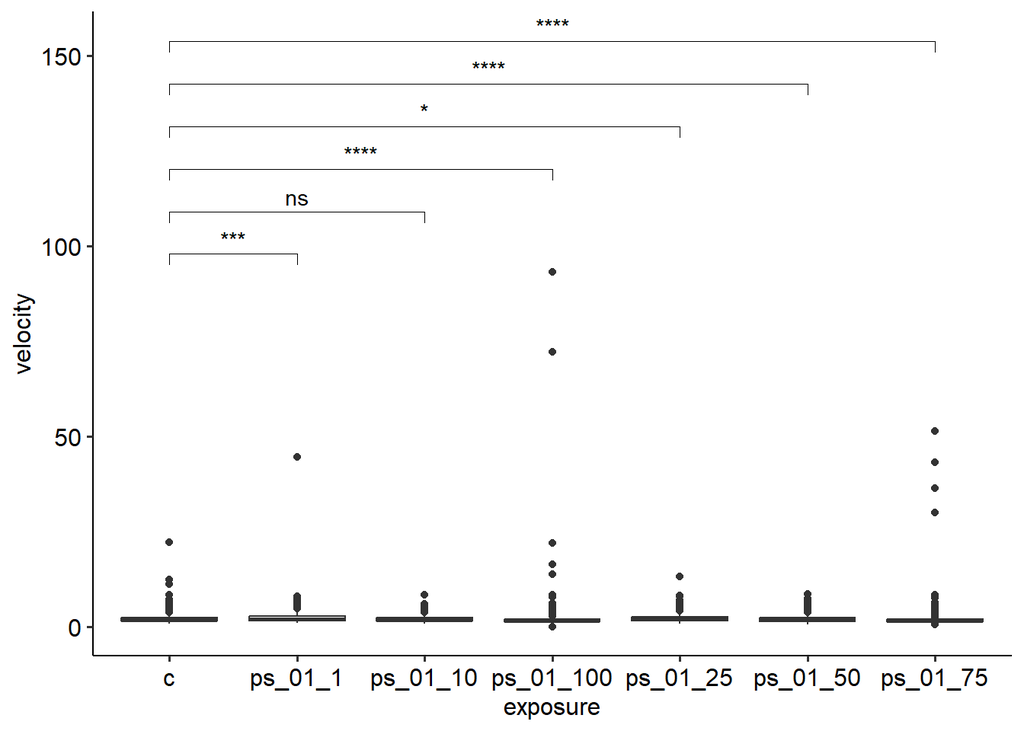

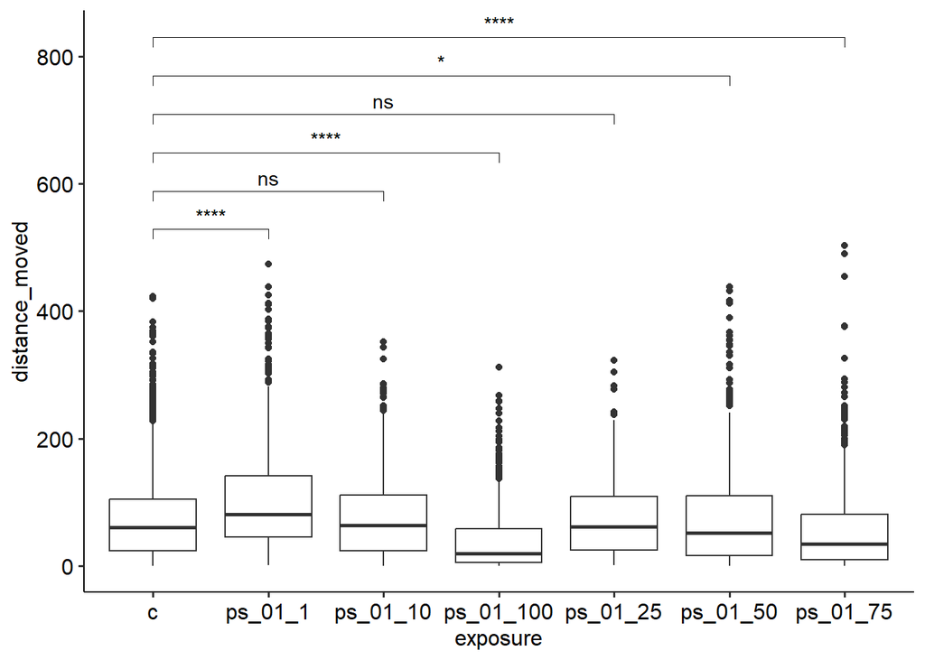

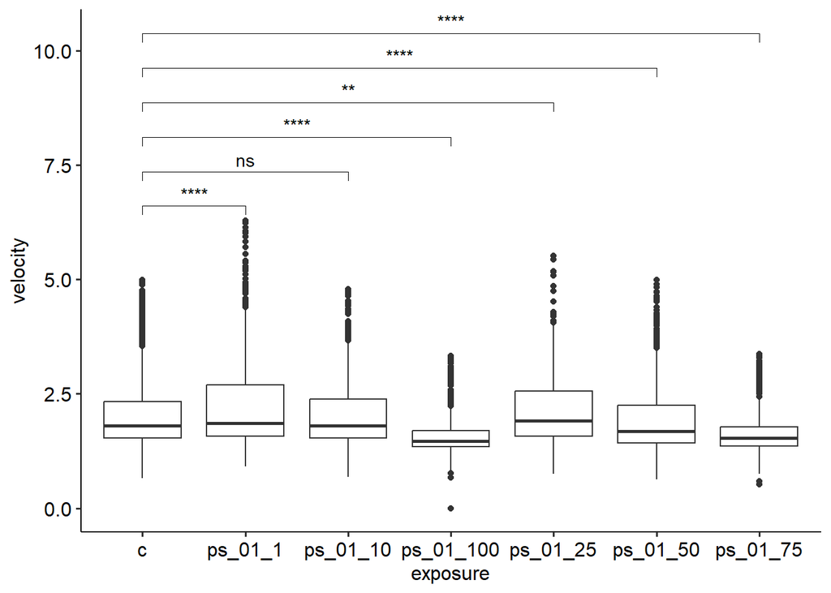

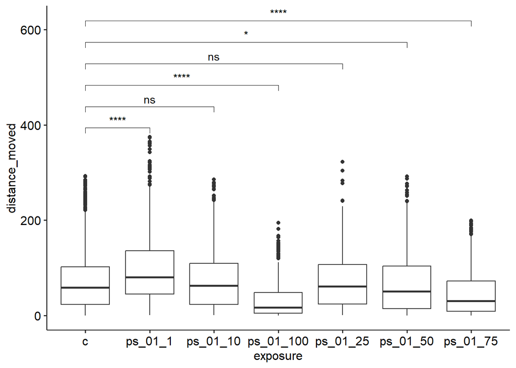

#### Distributions

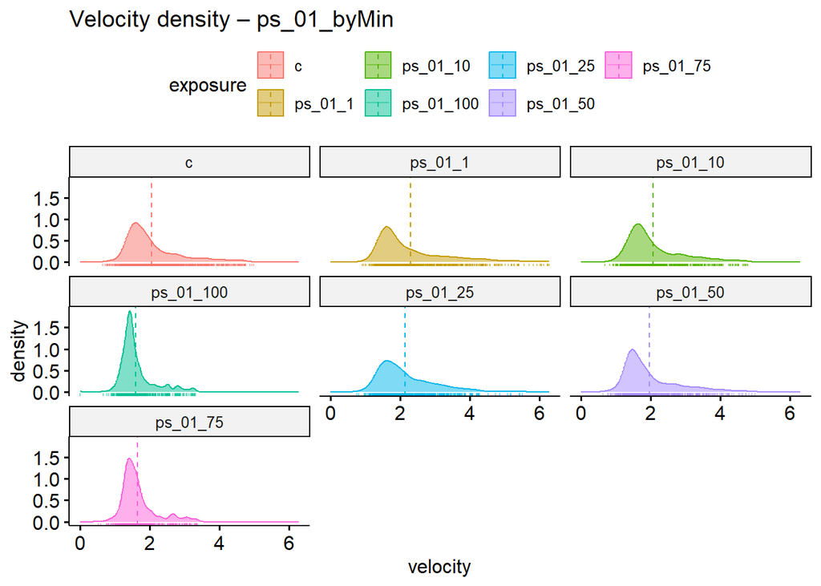

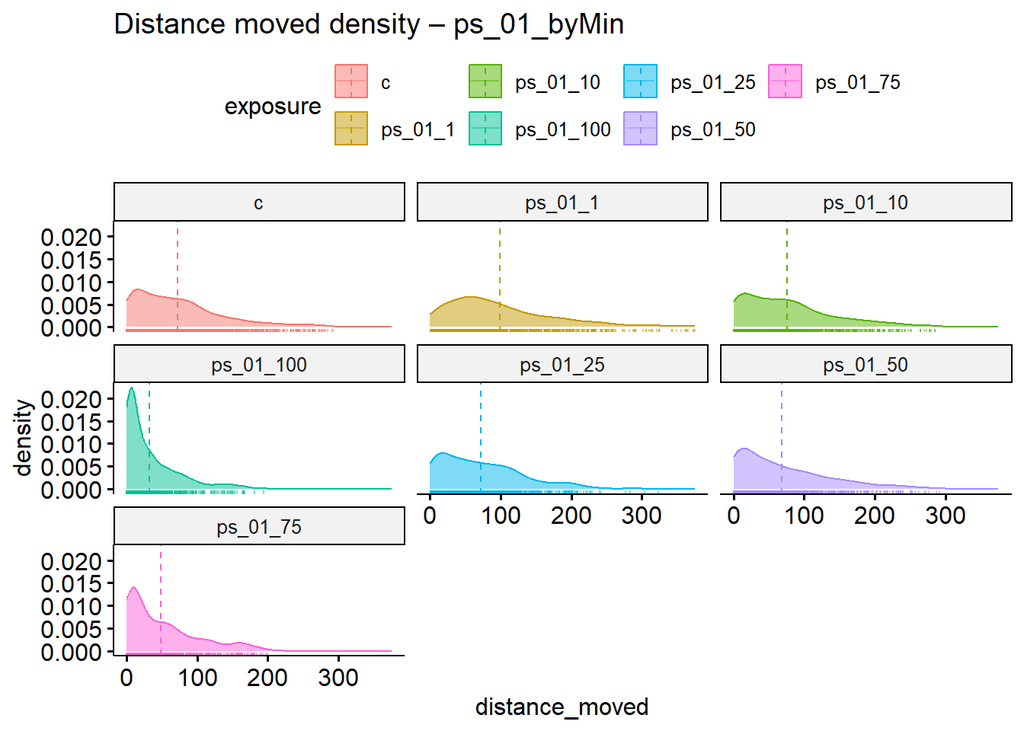

### PS MPs Distance/Velocity

**Stats**

**Note**

**Groups:** c, ps_5_1, ps_5_10, ps_5_100, ps_5_25, ps_5_50, ps_5_75

**N per group (raw → clean):**

| group | n_raw | n_clean |
| --- | --- | --- |
| c | 1800 | 1608 |
| ps_5_1 | 900 | 820 |
| ps_5_10 | 900 | 797 |
| ps_5_100 | 900 | 776 |
| ps_5_25 | 900 | 837 |
| ps_5_50 | 900 | 843 |
| ps_5_75 | 900 | 868 |

| exposure | velocity_mean | velocity_sd | velocity_se | distance_moved_mean | distance_moved_sd | distance_moved_se |
| --- | --- | --- | --- | --- | --- | --- |
| c | 2.090 | 0.877 | 0.022 | 75.236 | 69.631 | 1.736 |
| ps_5_1 | 2.209 | 0.908 | 0.032 | 93.894 | 72.229 | 2.522 |
| ps_5_10 | 2.175 | 0.876 | 0.031 | 89.529 | 69.135 | 2.449 |
| ps_5_100 | 2.136 | 0.709 | 0.025 | 82.328 | 56.113 | 2.014 |
| ps_5_25 | 1.939 | 0.689 | 0.024 | 69.074 | 55.550 | 1.920 |
| ps_5_50 | 2.109 | 0.754 | 0.026 | 86.837 | 59.859 | 2.062 |
| ps_5_75 | 2.093 | 0.751 | 0.025 | 89.454 | 63.383 | 2.151 |

| dataset_name | test_metric | value | significance |
| --- | --- | --- | --- |
| ps_5_byMin | shapiro_statistic | 0.863 |  |
| ps_5_byMin | shapiro_p_value | 0.000 | *** |
| ps_5_byMin | levene_F_value | 10.380 |  |
| ps_5_byMin | levene_p_value | 0.000 | *** |
| ps_5_byMin | kruskal_H_statistic | 89.607 |  |
| ps_5_byMin | kruskal_df | 6.000 |  |
| ps_5_byMin | kruskal_p_value | 0.000 | *** |

| dataset_name | test_metric | value | significance |
| --- | --- | --- | --- |
| ps_5_byMin | shapiro_statistic | 0.930 |  |
| ps_5_byMin | shapiro_p_value | 0.000 | *** |
| ps_5_byMin | levene_F_value | 15.118 |  |
| ps_5_byMin | levene_p_value | 0.000 | *** |
| ps_5_byMin | kruskal_H_statistic | 123.540 |  |
| ps_5_byMin | kruskal_df | 6.000 |  |
| ps_5_byMin | kruskal_p_value | 0.000 | *** |

| comparison | z_statistic | p_value | p_adj | significance | effect |
| --- | --- | --- | --- | --- | --- |
| c - ps_5_1 | -4.208 | 0.000 | 0.001 | *** | Positive (ps_5_1 > c) |
| c - ps_5_10 | -3.997 | 0.000 | 0.001 | ** | Positive (ps_5_10 > c) |
| ps_5_1 - ps_5_10 | 0.150 | 0.881 | 1.000 |  |  |
| c - ps_5_100 | -5.588 | 0.000 | 0.000 | *** | Positive (ps_5_100 > c) |
| ps_5_1 - ps_5_100 | -1.271 | 0.204 | 1.000 |  |  |
| ps_5_10 - ps_5_100 | -1.410 | 0.159 | 1.000 |  |  |
| c - ps_5_25 | 3.036 | 0.002 | 0.050 |  |  |
| ps_5_1 - ps_5_25 | 6.309 | 0.000 | 0.000 | *** | Negative (ps_5_1 > ps_5_25) |
| ps_5_10 - ps_5_25 | 6.113 | 0.000 | 0.000 | *** | Negative (ps_5_10 > ps_5_25) |
| ps_5_100 - ps_5_25 | 7.498 | 0.000 | 0.000 | *** | Negative (ps_5_100 > ps_5_25) |
| c - ps_5_50 | -3.972 | 0.000 | 0.001 | ** | Positive (ps_5_50 > c) |
| ps_5_1 - ps_5_50 | 0.238 | 0.812 | 1.000 |  |  |
| ps_5_10 - ps_5_50 | 0.086 | 0.932 | 1.000 |  |  |
| ps_5_100 - ps_5_50 | 1.514 | 0.130 | 1.000 |  |  |
| ps_5_25 - ps_5_50 | -6.113 | 0.000 | 0.000 | *** | Positive (ps_5_50 > ps_5_25) |
| c - ps_5_75 | -2.640 | 0.008 | 0.174 |  |  |
| ps_5_1 - ps_5_75 | 1.425 | 0.154 | 1.000 |  |  |
| ps_5_10 - ps_5_75 | 1.263 | 0.207 | 1.000 |  |  |
| ps_5_100 - ps_5_75 | 2.693 | 0.007 | 0.149 |  |  |
| ps_5_25 - ps_5_75 | -4.966 | 0.000 | 0.000 | *** | Positive (ps_5_75 > ps_5_25) |
| ps_5_50 - ps_5_75 | 1.194 | 0.233 | 1.000 |  |  |

| comparison | z_statistic | p_value | p_adj | significance | effect |
| --- | --- | --- | --- | --- | --- |
| c - ps_5_1 | -7.072 | 0.000 | 0 | *** | Positive (ps_5_1 > c) |
| c - ps_5_10 | -5.947 | 0.000 | 0 | *** | Positive (ps_5_10 > c) |
| ps_5_1 - ps_5_10 | 0.922 | 0.357 | 1 |  |  |
| c - ps_5_100 | -5.014 | 0.000 | 0 | *** | Positive (ps_5_100 > c) |
| ps_5_1 - ps_5_100 | 1.684 | 0.092 | 1 |  |  |
| ps_5_10 - ps_5_100 | 0.763 | 0.445 | 1 |  |  |
| c - ps_5_25 | 0.652 | 0.514 | 1 |  |  |
| ps_5_1 - ps_5_25 | 6.742 | 0.000 | 0 | *** | Negative (ps_5_1 > ps_5_25) |
| ps_5_10 - ps_5_25 | 5.767 | 0.000 | 0 | *** | Negative (ps_5_10 > ps_5_25) |
| ps_5_100 - ps_5_25 | 4.955 | 0.000 | 0 | *** | Negative (ps_5_100 > ps_5_25) |
| c - ps_5_50 | -6.432 | 0.000 | 0 | *** | Positive (ps_5_50 > c) |
| ps_5_1 - ps_5_50 | 0.611 | 0.541 | 1 |  |  |
| ps_5_10 - ps_5_50 | -0.321 | 0.748 | 1 |  |  |
| ps_5_100 - ps_5_50 | -1.093 | 0.274 | 1 |  |  |
| ps_5_25 - ps_5_50 | -6.175 | 0.000 | 0 | *** | Positive (ps_5_50 > ps_5_25) |
| c - ps_5_75 | -6.921 | 0.000 | 0 | *** | Positive (ps_5_75 > c) |
| ps_5_1 - ps_5_75 | 0.246 | 0.805 | 1 |  |  |
| ps_5_10 - ps_5_75 | -0.690 | 0.490 | 1 |  |  |
| ps_5_100 - ps_5_75 | -1.464 | 0.143 | 1 |  |  |
| ps_5_25 - ps_5_75 | -6.591 | 0.000 | 0 | *** | Positive (ps_5_75 > ps_5_25) |
| ps_5_50 - ps_5_75 | -0.372 | 0.710 | 1 |  |  |

**Plots**

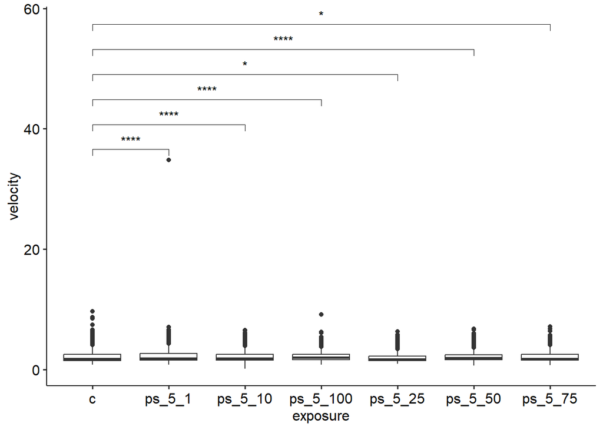

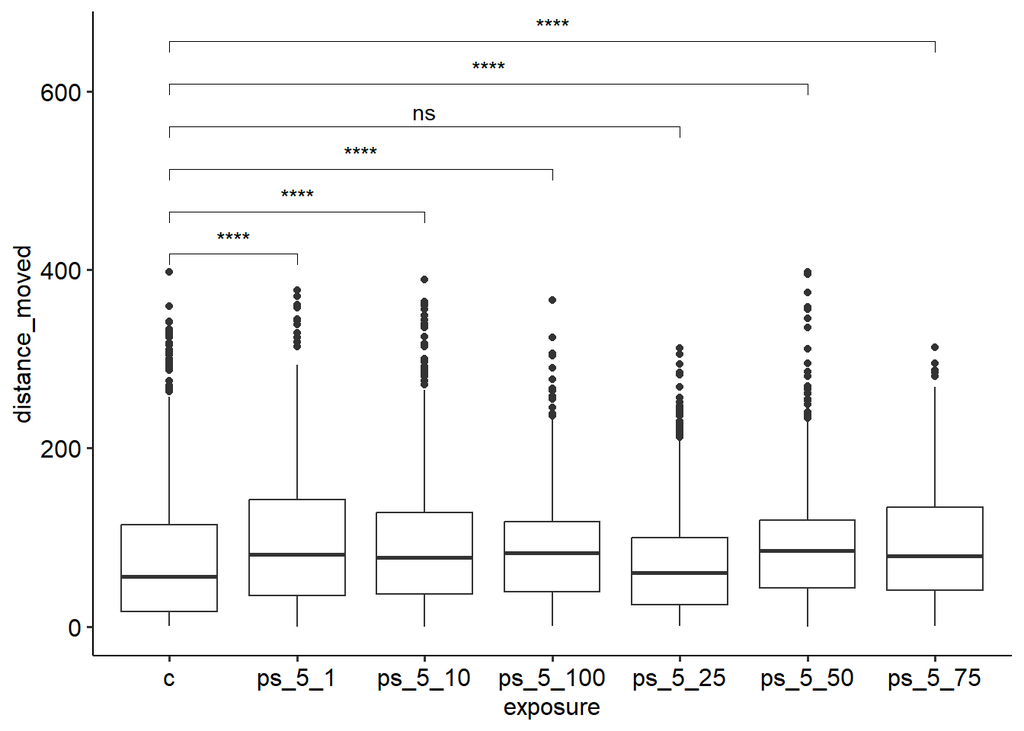

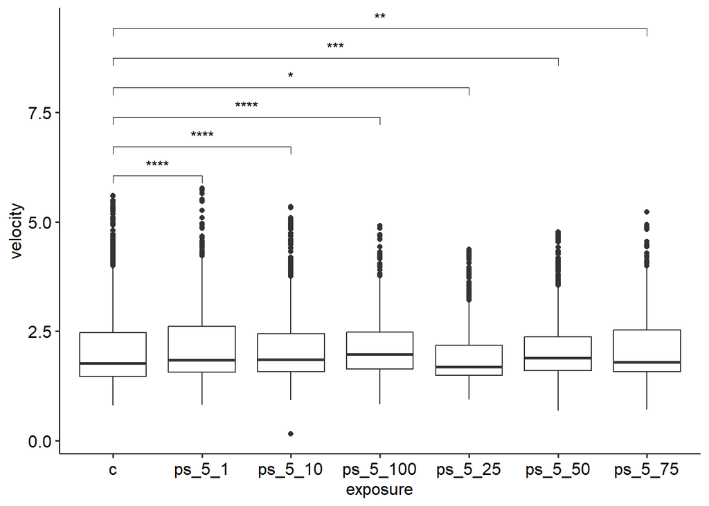

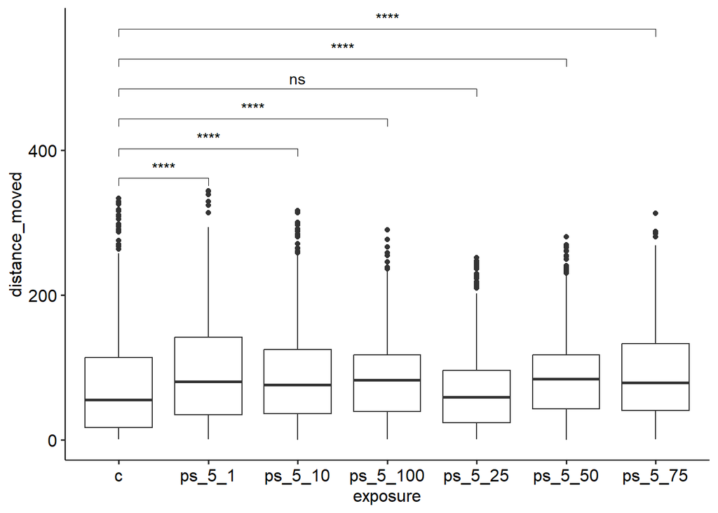

#### Distributions

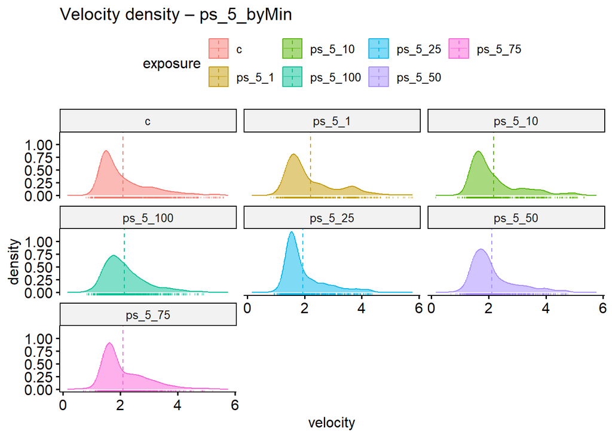

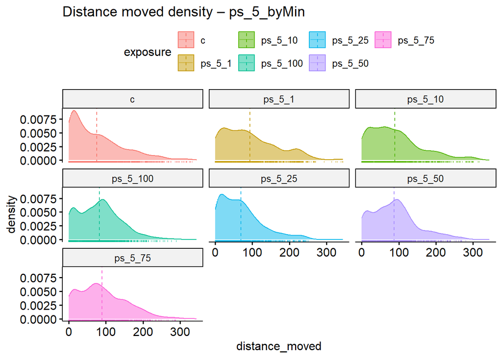

```r
## Activity
purrr::walk(activity_names, function(name) {
  data <- behavior_files_list[[name]] |>
  dplyr::mutate(Material = relabel_levels(Material))
  n_tbl <- as.data.frame(table(data$Material)) |> dplyr::rename(group = Var1, n = Freq)

## Section heading (in ToC) — remapped material; keep "activity" suffix
cat("\n\n### ", pretty_section_name(name), "\n\n", sep = "")

  ## Open tabset
  cat("::: {.panel-tabset}\n\n", sep = "")

  ## --- Stats tab ---
  cat("#### Stats\n\n", sep = "")
  cat("::: callout-note\n", sep = "")
  cat("**Groups:** ", paste(levels(data$Material), collapse = ", "), "\n\n", sep = "")
  cat("**N per group:**\n\n", sep = "")
  print(knitr::kable(n_tbl, format = "pipe"))
  cat("\n:::\n\n", sep = "")

  summarise_behavior(data, Material, c("Active_percent"))
  run_stats(data, Active_percent ~ Material, name)
  run_dunn_test(data, "Active_percent", "Material",
                save_path = "results_FINAL/Activity/dunn_results", label = name)

  ## --- Plots tab ---
  cat("\n#### Plots\n\n", sep = "")
  safe_print_plot(plot_with_wilcox(data, Active_percent, Material))

  ## --- Distributions tab ---
  cat("\n#### Distributions\n\n", sep = "")
  p_dens <- ggdensity(data, x = "Active_percent", fill = "Material",
                      add = "mean", rug = TRUE, color = "Material") +
            facet_wrap(~ Material) +
            labs(title = paste("Active % density –", name))
  safe_print_plot(p_dens)

  ## close tabset
  cat("\n:::\n", sep = "")
})
```

### PE MPs_activity

**Stats**

**Note**

**Groups:** c, hdpe_0005, hdpe_001, hdpe_01, hdpe_1, hdpe_10, hdpe_100, hdpe_25, hdpe_50, hdpe_75

**N per group:**

| group | n |
| --- | --- |
| c | 54 |
| hdpe_0005 | 6 |
| hdpe_001 | 6 |
| hdpe_01 | 6 |
| hdpe_1 | 30 |
| hdpe_10 | 30 |
| hdpe_100 | 30 |
| hdpe_25 | 30 |
| hdpe_50 | 30 |
| hdpe_75 | 30 |

| Material | Active_percent_mean | Active_percent_sd | Active_percent_se |
| --- | --- | --- | --- |
| c | 45.794 | 21.252 | 2.892 |
| hdpe_0005 | 46.483 | 34.102 | 13.922 |
| hdpe_001 | 34.625 | 29.174 | 11.910 |
| hdpe_01 | 52.372 | 17.131 | 6.994 |
| hdpe_1 | 51.912 | 27.904 | 5.095 |
| hdpe_10 | 42.745 | 25.338 | 4.626 |
| hdpe_100 | 41.617 | 22.510 | 4.110 |
| hdpe_25 | 42.746 | 27.681 | 5.054 |
| hdpe_50 | 36.152 | 22.400 | 4.090 |
| hdpe_75 | 36.805 | 30.567 | 5.581 |

| dataset_name | test_metric | value | significance |
| --- | --- | --- | --- |
| hdpe_activity | shapiro_statistic | 0.966 |  |
| hdpe_activity | shapiro_p_value | 0.000 | *** |
| hdpe_activity | levene_F_value | 1.563 |  |
| hdpe_activity | levene_p_value | 0.127 |  |
| hdpe_activity | kruskal_H_statistic | 10.560 |  |
| hdpe_activity | kruskal_df | 9.000 |  |
| hdpe_activity | kruskal_p_value | 0.307 |  |

| comparison | z_statistic | p_value | p_adj | significance | effect |
| --- | --- | --- | --- | --- | --- |
| c - hdpe_0005 | 0.134 | 0.893 | 1.000 |  |  |
| c - hdpe_001 | 1.117 | 0.264 | 1.000 |  |  |
| hdpe_0005 - hdpe_001 | 0.733 | 0.464 | 1.000 |  |  |
| c - hdpe_01 | -0.663 | 0.507 | 1.000 |  |  |
| hdpe_0005 - hdpe_01 | -0.594 | 0.552 | 1.000 |  |  |
| hdpe_001 - hdpe_01 | -1.327 | 0.185 | 1.000 |  |  |
| c - hdpe_1 | -0.928 | 0.354 | 1.000 |  |  |
| hdpe_0005 - hdpe_1 | -0.601 | 0.548 | 1.000 |  |  |
| hdpe_001 - hdpe_1 | -1.547 | 0.122 | 1.000 |  |  |
| hdpe_01 - hdpe_1 | 0.166 | 0.868 | 1.000 |  |  |
| c - hdpe_10 | 0.673 | 0.501 | 1.000 |  |  |
| hdpe_0005 - hdpe_10 | 0.214 | 0.831 | 1.000 |  |  |
| hdpe_001 - hdpe_10 | -0.732 | 0.464 | 1.000 |  |  |
| hdpe_01 - hdpe_10 | 0.981 | 0.327 | 1.000 |  |  |
| hdpe_1 - hdpe_10 | 1.412 | 0.158 | 1.000 |  |  |
| c - hdpe_100 | 0.779 | 0.436 | 1.000 |  |  |
| hdpe_0005 - hdpe_100 | 0.268 | 0.789 | 1.000 |  |  |
| hdpe_001 - hdpe_100 | -0.678 | 0.498 | 1.000 |  |  |
| hdpe_01 - hdpe_100 | 1.035 | 0.301 | 1.000 |  |  |
| hdpe_1 - hdpe_100 | 1.505 | 0.132 | 1.000 |  |  |
| hdpe_10 - hdpe_100 | 0.094 | 0.925 | 1.000 |  |  |
| c - hdpe_25 | 0.685 | 0.493 | 1.000 |  |  |
| hdpe_0005 - hdpe_25 | 0.220 | 0.826 | 1.000 |  |  |
| hdpe_001 - hdpe_25 | -0.726 | 0.468 | 1.000 |  |  |
| hdpe_01 - hdpe_25 | 0.987 | 0.324 | 1.000 |  |  |
| hdpe_1 - hdpe_25 | 1.422 | 0.155 | 1.000 |  |  |
| hdpe_10 - hdpe_25 | 0.011 | 0.992 | 1.000 |  |  |
| hdpe_100 - hdpe_25 | -0.083 | 0.934 | 1.000 |  |  |
| c - hdpe_50 | 1.721 | 0.085 | 1.000 |  |  |
| hdpe_0005 - hdpe_50 | 0.748 | 0.455 | 1.000 |  |  |
| hdpe_001 - hdpe_50 | -0.198 | 0.843 | 1.000 |  |  |
| hdpe_01 - hdpe_50 | 1.514 | 0.130 | 1.000 |  |  |
| hdpe_1 - hdpe_50 | 2.336 | 0.019 | 0.877 |  |  |
| hdpe_10 - hdpe_50 | 0.925 | 0.355 | 1.000 |  |  |
| hdpe_100 - hdpe_50 | 0.831 | 0.406 | 1.000 |  |  |
| hdpe_25 - hdpe_50 | 0.914 | 0.361 | 1.000 |  |  |
| c - hdpe_75 | 1.757 | 0.079 | 1.000 |  |  |
| hdpe_0005 - hdpe_75 | 0.766 | 0.444 | 1.000 |  |  |
| hdpe_001 - hdpe_75 | -0.180 | 0.857 | 1.000 |  |  |
| hdpe_01 - hdpe_75 | 1.533 | 0.125 | 1.000 |  |  |
| hdpe_1 - hdpe_75 | 2.368 | 0.018 | 0.805 |  |  |
| hdpe_10 - hdpe_75 | 0.956 | 0.339 | 1.000 |  |  |
| hdpe_100 - hdpe_75 | 0.863 | 0.388 | 1.000 |  |  |
| hdpe_25 - hdpe_75 | 0.946 | 0.344 | 1.000 |  |  |
| hdpe_50 - hdpe_75 | 0.032 | 0.975 | 1.000 |  |  |

**Plots**

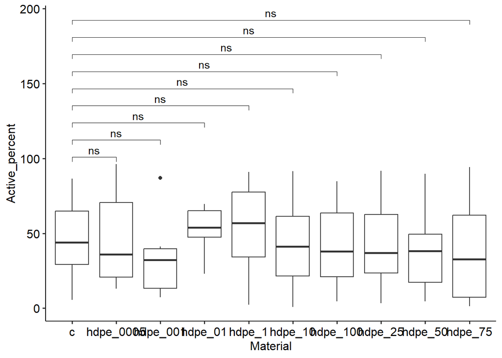

#### Distributions

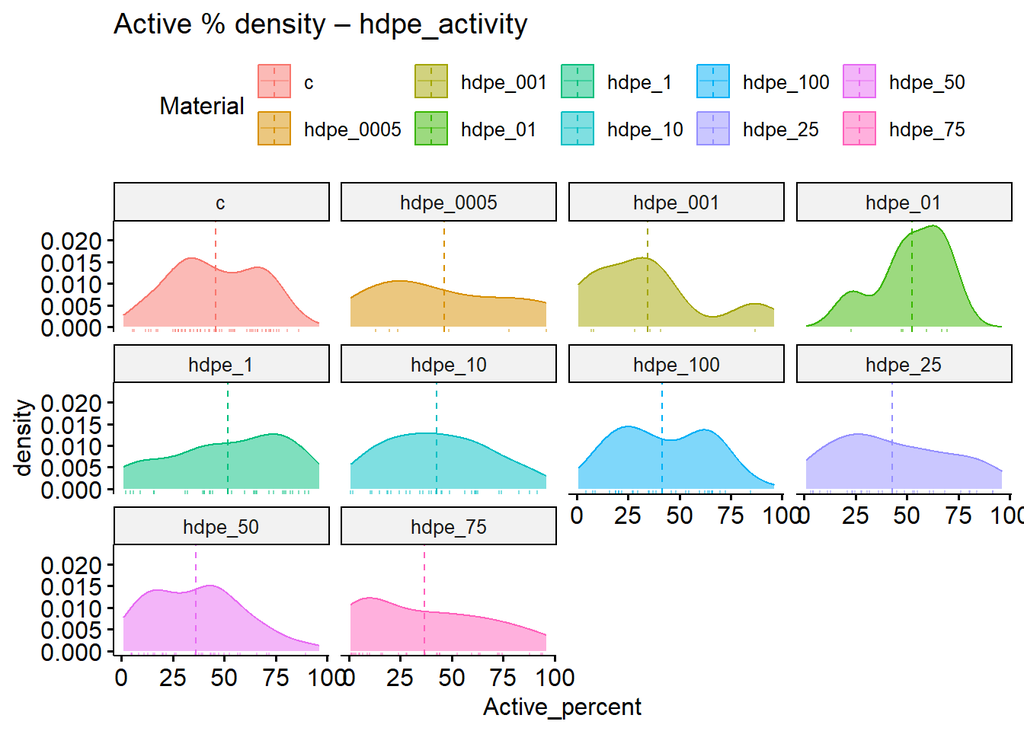

### PE NPs_activity

**Stats**

**Note**

**Groups:** c, pen_001, pen_01, pen_1, pen_10, pen_5

**N per group:**

| group | n |
| --- | --- |
| c | 20 |
| pen_001 | 36 |
| pen_01 | 36 |
| pen_1 | 12 |
| pen_10 | 12 |
| pen_5 | 12 |

| Material | Active_percent_mean | Active_percent_sd | Active_percent_se |
| --- | --- | --- | --- |
| c | 39.480 | 24.976 | 5.585 |
| pen_001 | 38.983 | 21.080 | 3.513 |
| pen_01 | 56.609 | 24.878 | 4.146 |
| pen_1 | 48.818 | 27.003 | 7.795 |
| pen_10 | 34.418 | 18.182 | 5.249 |
| pen_5 | 49.690 | 23.074 | 6.661 |

| dataset_name | test_metric | value | significance |
| --- | --- | --- | --- |
| pen_activity | shapiro_statistic | 0.976 |  |
| pen_activity | shapiro_p_value | 0.020 | * |
| pen_activity | levene_F_value | 0.809 |  |
| pen_activity | levene_p_value | 0.546 |  |
| pen_activity | kruskal_H_statistic | 12.298 |  |
| pen_activity | kruskal_df | 5.000 |  |
| pen_activity | kruskal_p_value | 0.031 | * |

| comparison | z_statistic | p_value | p_adj | significance | effect |
| --- | --- | --- | --- | --- | --- |
| c - pen_001 | -0.097 | 0.923 | 1.000 |  |  |
| c - pen_01 | -2.402 | 0.016 | 0.245 |  |  |
| pen_001 - pen_01 | -2.728 | 0.006 | 0.096 |  |  |
| c - pen_1 | -1.080 | 0.280 | 1.000 |  |  |
| pen_001 - pen_1 | -1.102 | 0.270 | 1.000 |  |  |
| pen_01 - pen_1 | 0.827 | 0.408 | 1.000 |  |  |
| c - pen_10 | 0.477 | 0.633 | 1.000 |  |  |
| pen_001 - pen_10 | 0.603 | 0.546 | 1.000 |  |  |
| pen_01 - pen_10 | 2.532 | 0.011 | 0.170 |  |  |
| pen_1 - pen_10 | 1.392 | 0.164 | 1.000 |  |  |
| c - pen_5 | -1.252 | 0.211 | 1.000 |  |  |
| pen_001 - pen_5 | -1.291 | 0.197 | 1.000 |  |  |
| pen_01 - pen_5 | 0.638 | 0.523 | 1.000 |  |  |
| pen_1 - pen_5 | -0.154 | 0.878 | 1.000 |  |  |
| pen_10 - pen_5 | -1.546 | 0.122 | 1.000 |  |  |

**Plots**

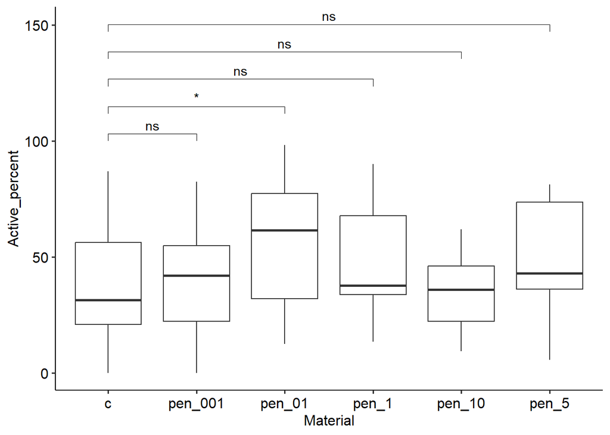

#### Distributions

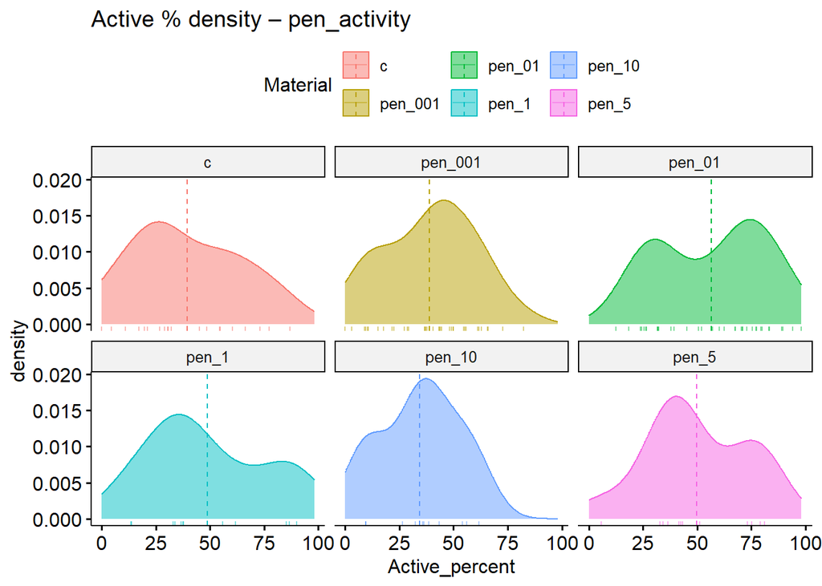

### PS NPs_activity

**Stats**

**Note**

**Groups:** c, ps_01_1, ps_01_10, ps_01_100, ps_01_25, ps_01_50, ps_01_75

**N per group:**

| group | n |
| --- | --- |
| c | 36 |
| ps_01_1 | 18 |
| ps_01_10 | 18 |
| ps_01_100 | 18 |
| ps_01_25 | 18 |
| ps_01_50 | 18 |
| ps_01_75 | 18 |

| Material | Active_percent_mean | Active_percent_sd | Active_percent_se |
| --- | --- | --- | --- |
| c | 47.282 | 18.355 | 3.059 |
| ps_01_1 | 62.375 | 18.770 | 4.424 |
| ps_01_10 | 47.480 | 20.053 | 4.727 |
| ps_01_100 | 23.193 | 14.896 | 3.511 |
| ps_01_25 | 41.988 | 21.496 | 5.067 |
| ps_01_50 | 44.420 | 23.500 | 5.539 |
| ps_01_75 | 36.271 | 24.941 | 5.879 |

| dataset_name | test_metric | value | significance |
| --- | --- | --- | --- |
| ps_01_activity | shapiro_statistic | 0.976 |  |
| ps_01_activity | shapiro_p_value | 0.011 | * |
| ps_01_activity | levene_F_value | 1.184 |  |
| ps_01_activity | levene_p_value | 0.318 |  |
| ps_01_activity | kruskal_H_statistic | 30.411 |  |
| ps_01_activity | kruskal_df | 6.000 |  |
| ps_01_activity | kruskal_p_value | 0.000 | *** |

| comparison | z_statistic | p_value | p_adj | significance | effect |
| --- | --- | --- | --- | --- | --- |
| c - ps_01_1 | -2.136 | 0.033 | 0.686 |  |  |
| c - ps_01_10 | -0.005 | 0.996 | 1.000 |  |  |
| ps_01_1 - ps_01_10 | 1.846 | 0.065 | 1.000 |  |  |
| c - ps_01_100 | 3.769 | 0.000 | 0.003 | ** | Negative (c > ps_01_100) |
| ps_01_1 - ps_01_100 | 5.114 | 0.000 | 0.000 | *** | Negative (ps_01_1 > ps_01_100) |
| ps_01_10 - ps_01_100 | 3.268 | 0.001 | 0.023 | * | Negative (ps_01_10 > ps_01_100) |
| c - ps_01_25 | 0.941 | 0.347 | 1.000 |  |  |
| ps_01_1 - ps_01_25 | 2.665 | 0.008 | 0.162 |  |  |
| ps_01_10 - ps_01_25 | 0.819 | 0.413 | 1.000 |  |  |
| ps_01_100 - ps_01_25 | -2.449 | 0.014 | 0.301 |  |  |
| c - ps_01_50 | 0.535 | 0.593 | 1.000 |  |  |
| ps_01_1 - ps_01_50 | 2.313 | 0.021 | 0.435 |  |  |
| ps_01_10 - ps_01_50 | 0.467 | 0.640 | 1.000 |  |  |
| ps_01_100 - ps_01_50 | -2.801 | 0.005 | 0.107 |  |  |
| ps_01_25 - ps_01_50 | -0.352 | 0.725 | 1.000 |  |  |
| c - ps_01_75 | 1.841 | 0.066 | 1.000 |  |  |
| ps_01_1 - ps_01_75 | 3.444 | 0.001 | 0.012 | * | Negative (ps_01_1 > ps_01_75) |
| ps_01_10 - ps_01_75 | 1.598 | 0.110 | 1.000 |  |  |
| ps_01_100 - ps_01_75 | -1.670 | 0.095 | 1.000 |  |  |
| ps_01_25 - ps_01_75 | 0.779 | 0.436 | 1.000 |  |  |
| ps_01_50 - ps_01_75 | 1.131 | 0.258 | 1.000 |  |  |

**Plots**

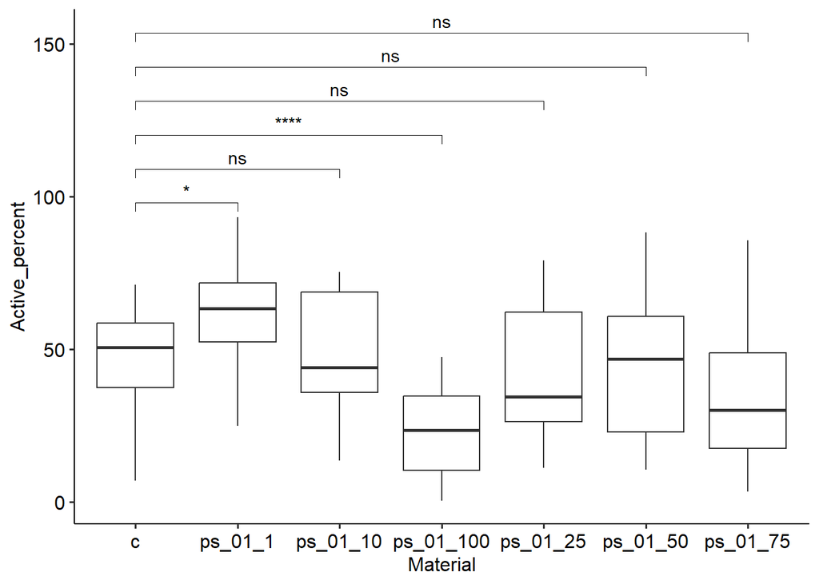

#### Distributions

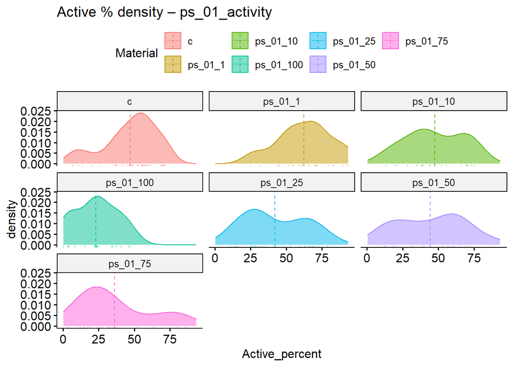

### PS MPs_activity

**Stats**

**Note**

**Groups:** c, ps_5_1, ps_5_10, ps_5_100, ps_5_25, ps_5_50, ps_5_75

**N per group:**

| group | n |
| --- | --- |
| c | 36 |
| ps_5_1 | 18 |
| ps_5_10 | 18 |
| ps_5_100 | 18 |
| ps_5_25 | 18 |
| ps_5_50 | 18 |
| ps_5_75 | 18 |

| Material | Active_percent_mean | Active_percent_sd | Active_percent_se |
| --- | --- | --- | --- |
| c | 45.980 | 20.806 | 3.468 |
| ps_5_1 | 57.543 | 20.187 | 4.758 |
| ps_5_10 | 55.497 | 23.600 | 5.563 |
| ps_5_100 | 51.164 | 26.161 | 6.166 |
| ps_5_25 | 50.515 | 14.465 | 3.409 |
| ps_5_50 | 59.647 | 22.461 | 5.294 |
| ps_5_75 | 61.834 | 23.443 | 5.526 |

| dataset_name | test_metric | value | significance |
| --- | --- | --- | --- |
| ps_5_activity | shapiro_statistic | 0.968 |  |
| ps_5_activity | shapiro_p_value | 0.002 | ** |
| ps_5_activity | levene_F_value | 0.956 |  |
| ps_5_activity | levene_p_value | 0.458 |  |
| ps_5_activity | kruskal_H_statistic | 10.658 |  |
| ps_5_activity | kruskal_df | 6.000 |  |
| ps_5_activity | kruskal_p_value | 0.100 |  |

| comparison | z_statistic | p_value | p_adj | significance | effect |
| --- | --- | --- | --- | --- | --- |
| c - ps_5_1 | -1.587 | 0.112 | 1.000 |  |  |
| c - ps_5_10 | -1.463 | 0.144 | 1.000 |  |  |
| ps_5_1 - ps_5_10 | 0.108 | 0.914 | 1.000 |  |  |
| c - ps_5_100 | -1.070 | 0.284 | 1.000 |  |  |
| ps_5_1 - ps_5_100 | 0.447 | 0.655 | 1.000 |  |  |
| ps_5_10 - ps_5_100 | 0.340 | 0.734 | 1.000 |  |  |
| c - ps_5_25 | -0.531 | 0.596 | 1.000 |  |  |
| ps_5_1 - ps_5_25 | 0.915 | 0.360 | 1.000 |  |  |
| ps_5_10 - ps_5_25 | 0.807 | 0.420 | 1.000 |  |  |
| ps_5_100 - ps_5_25 | 0.467 | 0.640 | 1.000 |  |  |
| c - ps_5_50 | -2.275 | 0.023 | 0.482 |  |  |
| ps_5_1 - ps_5_50 | -0.595 | 0.552 | 1.000 |  |  |
| ps_5_10 - ps_5_50 | -0.703 | 0.482 | 1.000 |  |  |
| ps_5_100 - ps_5_50 | -1.043 | 0.297 | 1.000 |  |  |
| ps_5_25 - ps_5_50 | -1.510 | 0.131 | 1.000 |  |  |
| c - ps_5_75 | -2.745 | 0.006 | 0.127 |  |  |
| ps_5_1 - ps_5_75 | -1.003 | 0.316 | 1.000 |  |  |
| ps_5_10 - ps_5_75 | -1.111 | 0.267 | 1.000 |  |  |
| ps_5_100 - ps_5_75 | -1.450 | 0.147 | 1.000 |  |  |
| ps_5_25 - ps_5_75 | -1.918 | 0.055 | 1.000 |  |  |
| ps_5_50 - ps_5_75 | -0.408 | 0.684 | 1.000 |  |  |

**Plots**

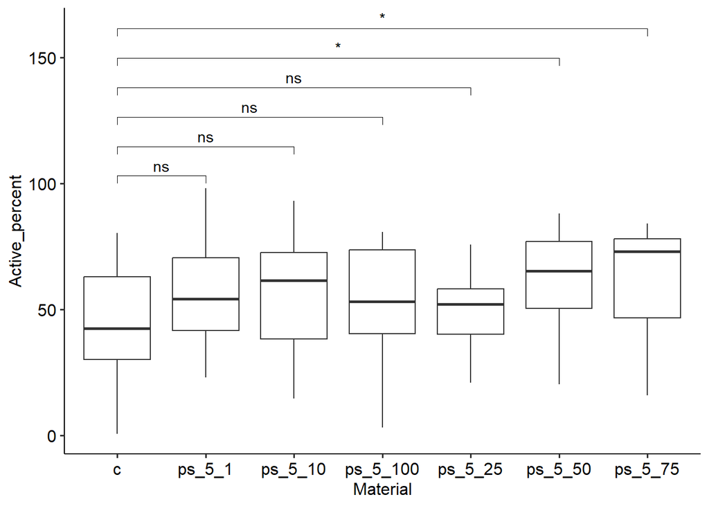

#### Distributions

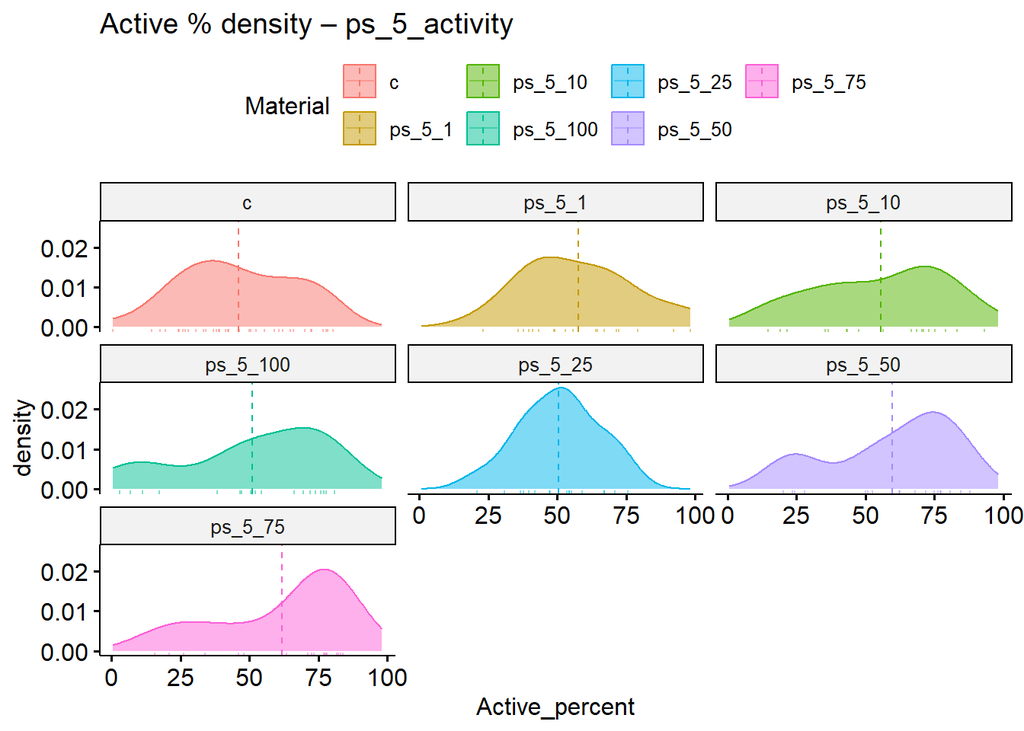